# Master’s thesis - Application of Machine Learning Methods to Forecast Trends Based on Metadata from Scientific Literature

Valeria Giraldo Carvajal

January 2023

# 1 General introduction

This RMarkdown file is an important part of a master’s thesis in the context of the joint master’s degree on Bioinformatics of Biostatistics of the University of Barcelona (UB) and the Open University of Catalonia (UOC). The present work is focused on researching whether trends in scientific literature could be effectively predicted using metadata obtained from scientific publications and machine learning.

The ultimate goal of the project is to evaluate whether metadata present in a pool of scientific publications can be useful to forecast trends within a certain field. In the scope of this project, the topic of gene and genome editing has been selected as a case study and Scopus as a scientific database. In this context, the dataset to study will contain scientific metadata from a pool of documents mentioning gene and genome editing.

## 1.1 Objective of this RMarkdown

All the data- and modelling-related work of the project is explained and presented in this file. The idea of this file is to standardize the code so that it can be applied to different data sets.

# 2 Extracting the scientific literature pool and preprocessing the database

This first section is focused on obtaining a scientific literature pool from Scopus. For this reason and to extract all the relevant scientific metadata available from Scopus, the Scopus API is used. More details on the Scopus API are given below. Beyond that, for future case studies, it is important to highlight the fact that having some basic knowledge on advanced querying in Scopus is required. For more information, it is recommended to access [Scopus - Advanced searches](https://www.scopus.com/search/form.uri?display=advanced).

## 2.1 Preparing the R environment

The first step is to define the working directory of the project. This is done below:

```r
# define working directory
# setwd("")

# check that working directory is correct
# getwd()
```

Then, we must install or load the packages needed and set the paths to the relevant directories. For obtaining the scientific literature pool the packages “XLM” and “httr” are needed. The chunk below implements a conditional loop where if the packages are not installed yet, then they are first installed, and once all are installed they are loaded into the R environment.

```r
# define the list of packages to download or to load
package_list <- c(
  "rscopus",
  "XML",
  "httr",
  "stringr",
  "rpart",
  "rpart.plot",
  "rattle",
  "RColorBrewer",
  "ggplot2",
  "dplyr",
  "readxl",
  "DataExplorer",
  "vtree",
  "crosstable",
  "caret",
  "kernlab",
  "randomForest",
  "pscl",
  "dplyr",
  "MASS",
  "pROC",
  "descr",
  "rminer"
)
# loop to download new packages and then load all of the packages from the list
for (p in package_list) {
  if (p %in% installed.packages() == FALSE) {
    install.packages(p, dependencies = TRUE)
  }
  library(p, character.only = TRUE)
}
```

## 2.2 Using the Scopus Search API

First of all, it is important to remark that an API key is needed in order to use the Scopus API. All users with Scopus subscriptions are given an API key associated to their account. This allows you to download larger datasets from Scopus. An API key can be requested in the [Elsevier Developer Portal](https://dev.elsevier.com/).

Once that has been clarified, it is time to save the advance Scopus query to gather the scientific literature pool related to the selected case study. As explained before, in this case, it is focused on gene/genome editing.

After it has been defined, we must run the query using the “Scopus Search API” through the aforementioned package RScopus.

In this step, we obtain raw data with extra added information in it. The idea is that once the raw data (with the added metadata) has been extracted, it can be converted into a data frame for further processing in R.

As explained by [Christopher Belter](https://github.com/christopherBelter/scopusAPI), there are some API limits one must be aware of:

- If you want to download the full records of your search results (inlcuding the full author list and abstract for each document), you are limited to requesting 25 articles at a time.
- You can only request the first 5,000 records using the ‘offset’ parameter. This used to mean that you could only request up to 5,000 records for a single search string, but Elsevier has added a new ‘cursor’ parameter that allows you to bypass this limit.
- You are limited to downloading 20,000 records per week.

### 2.2.1 Defining the advanced search query

The search query on the selected case study about gene/genome editing must be now defined. Taking into account the limitations of the Scopus API and the fact that the total query had ~30000 document results, it has been divided in two parts. These two parts are split depending on the Scopus ID of the publications, which is a reasonably evenly distributed parameter, which means that around half of the results are covered by the first part of the query and the other half by the second part. Beyond that, some noise has been excluded from the pool (e.g. general editor, generic edition).

```r
# save the search query you to use
# part 1 of the query
myQuery <- '(TITLE-ABS-KEY("gen* edit*") AND NOT TITLE-ABS-KEY("general edit*" OR "generic edit*" OR "genuine edit*")) AND EID(*0 OR *1 OR *2 OR *3 OR *4)'

# part 2 of the query
myQuery2 <- '(TITLE-ABS-KEY("gen* edit*") AND NOT TITLE-ABS-KEY("general edit*" OR "generic edit*" OR "genuine edit*")) AND EID(*5 OR *6 OR *7 OR *8 OR *9)'
```

Now the Scopus query has been succesfully defined.

### 2.2.2 Running the advanced Scopus search through the Scopus API

To run the advanced Scopus search through the API the method “searchByString()” designed by Christopher Belter is used.

The “searchByString()” function allows you to run an advanced search through the API and download all of the search results. The “searchByString()” function automatically sends multiple requests to the API to retrieve the full set of search results for your particular query. However, as mentioned before, it can only retrieve 25 full records at a time. It is a function with eight arguments: string, content, myStart, retCount, retMax, mySort, cursor, and outfile. For more details regarding the arguments, please access the [Christopher Belter’s GitHub](https://github.com/christopherBelter/scopusAPI).

The output of the “searchByString()” is an XML file. For this, the “extractXML()” function also designed by Christopher Balter is very useful. This function converts the output XML file into a data frame. The original “extractXML()” function proposed by Christopher Balter has been adapted in the scope of this project. That has been done to extract more metadata (from the output XML) than the initially proposed in the original function.

Before running any searches, the functions “searchByString()” and “extractXML()” must be defined. The personal Scopus API key must be incorporated in the variable “key”.

```r
# define searchByString
# version 0.4 of the function defined by Christopher Belter
searchByString <- function(string, content = "complete", myStart = 0, retCount = 25, retMax = Inf, mySort = "-coverDate", cursor = "*", outfile) {
    if (!content %in% c("complete", "standard")) {
        stop("Invalid content value. Valid content values are 'complete', and 'standard'")
    }
    else {
        key <- "55fe4bf5db6afca7a17bde084e5dc77a"
        print("Retrieving records.")
        theURL <- httr::GET("https://api.elsevier.com/content/search/scopus", query = list(apiKey = key, query = string, sort = mySort, httpAccept = "application/xml", view = content, count = retCount, start = myStart, cursor = cursor)) ## format the URL to be sent to the API
        httr::stop_for_status(theURL) ## pass any HTTP errors to the R console
        theData <- httr::content(theURL, as = "text") ## extract the content of the response
        newData <- XML::xmlParse(theURL) ## parse the data to extract values
        resultCount <- as.numeric(XML::xpathSApply(newData,"//opensearch:totalResults", XML::xmlValue)) ## get the total number of search results for the string
        cursor <- XML::xpathSApply(newData, "//cto:cursor", XML::xmlGetAttr, name = "next", namespaces = "cto")
        print(paste("Found", resultCount, "records."))
        retrievedCount <- retCount + myStart ## set the current number of results retrieved for the designated start and count parameters
        while (resultCount > retrievedCount && retrievedCount < retMax) { ## check if it's necessary to perform multiple requests to retrieve all of the results; if so, create a loop to retrieve additional pages of results
            myStart <- myStart + retCount ## add the number of records already returned to the start number
            print(paste("Retrieved", retrievedCount, "of", resultCount, "records. Getting more."))
            theURL <- httr::GET("https://api.elsevier.com/content/search/scopus", query = list(apiKey = key, query = string,  sort = mySort, httpAccept = "application/xml", view = content, count = retCount, cursor = cursor)) ## get the next page of results
            theData <- paste(theData, httr::content(theURL, as = "text")) ## paste new theURL content to theData; if there's an HTTP error, the XML of the error will be pasted to the end of theData
            newData <- httr::content(theURL, as = "text")
            newData <- XML::xmlParse(theURL)
            cursor <- XML::xpathSApply(newData, "//cto:cursor", XML::xmlGetAttr, name = "next", namespaces = "cto")
            if (httr::http_error(theURL) == TRUE) { ## check if there's an HTTP error
                print("Encountered an HTTP error. Details follow.") ## alert the user to the error
                print(httr::http_status(theURL)) ## print out the error category, reason, and message
                break ## if there's an HTTP error, break out of the loop and return the data that has been retrieved
                }
            retrievedCount <- retrievedCount + retCount ## add the number of results retrieved in this iteration to the total number of results retrieved
            Sys.sleep(1)
        } ## repeat until retrievedCount >= resultCount
        print(paste("Retrieved", retrievedCount, "records. Formatting and saving results."))
        writeLines(theData, outfile, useBytes = TRUE) ## if there were multiple pages of results, they come back as separate XML files pasted into the single outfile; the theData XML object can't be coerced into a string to do find/replace operations, so I think it must be written to a file and then reloaded; useBytes = TRUE keeps the UTF-8 encoding of special characters like the copyright symbol so they won't throw an error later
        theData <- readChar(outfile, file.info(outfile)$size) ## convert the XML results to a character vector of length 1 that can be manipulated
        theData <- gsub("<?xml version=\"1.0\" encoding=\"UTF-8\"?>", "", theData, fixed = TRUE, useBytes = TRUE)
        theData <- gsub("<search-results.+?>", "", theData, useBytes = TRUE)
        theData <- gsub("</search-results>", "", theData, fixed = TRUE) ## remove all headers and footers of the separate XML files
        theData <- paste("<?xml version=\"1.0\" encoding=\"UTF-8\"?>", "<search-results xmlns=\"http://www.w3.org/2005/Atom\" xmlns:cto=\"http://www.elsevier.com/xml/cto/dtd\" xmlns:atom=\"http://www.w3.org/2005/Atom\" xmlns:prism=\"http://prismstandard.org/namespaces/basic/2.0/\" xmlns:opensearch=\"http://a9.com/-/spec/opensearch/1.1/\" xmlns:dc=\"http://purl.org/dc/elements/1.1/\">", theData, "</search-results>", sep = "\n")
        #theData <- paste(theData, "</search-results>") ## add the correct header to the beginning of the file and the correct footer to the end of the file
        writeLines(theData, outfile, useBytes = TRUE) ## save the correctly formatted XML file
        print("Done")
        return(theData) ## return the final, correctly formatted XML file
    }
}


# define the adapted version of the extractXML function from Christopher Belter

extractXML_adapted <- function(theFile) {
    newData <- XML::xmlParse(theFile) ## parse the XML
    records <- XML::getNodeSet(newData, "//cto:entry", namespaces = "cto") ## create a list of records for missing or duplicate node handling
    scopusID <- lapply(records, XML::xpathSApply, "./cto:eid", XML::xmlValue, namespaces = "cto") ## handle potentially missing eid nodes
    scopusID[sapply(scopusID, is.list)] <- NA
    scopusID <- unlist(scopusID)
    doi <- lapply(records, XML::xpathSApply, "./prism:doi", XML::xmlValue, namespaces = c(prism = "http://prismstandard.org/namespaces/basic/2.0/")) ## handle potentially missing doi nodes
    doi[sapply(doi, is.list)] <- NA
    doi <- unlist(doi)
    pmid <- lapply(records, XML::xpathSApply, "./cto:pubmed-id", XML::xmlValue, namespaces = "cto") ## handle potentially missing pmid nodes: returns a list with the node value if the node is present and an empty list if the node is missing
    pmid[sapply(pmid, is.list)] <- NA ## find the empty lists in pmid and set them to NA
    pmid <- unlist(pmid) ## turn the pmid list into a vector
    authLast <- lapply(records, XML::xpathSApply, ".//cto:surname", XML::xmlValue, namespaces = "cto") ## grab the surname and initials for each author in each record, then paste them together
    authLast[sapply(authLast, is.list)] <- NA
    authInit <- lapply(records, XML::xpathSApply, ".//cto:initials", XML::xmlValue, namespaces = "cto")
    authInit[sapply(authInit, is.list)] <- NA
    authors <- mapply(paste, authLast, authInit, collapse = "|")
    authors <- sapply(strsplit(authors, "|", fixed = TRUE), unique) ## remove the duplicate author listings
    authors <- sapply(authors, paste, collapse = "|")
    affiliations <- lapply(records, XML::xpathSApply, ".//cto:affilname", XML::xmlValue, namespaces = "cto") ## handle multiple affiliation names
    affiliations[sapply(affiliations, is.list)] <- NA
    affiliations <- sapply(affiliations, paste, collapse = "|")
    affiliations <- sapply(strsplit(affiliations, "|", fixed = TRUE), unique) ## remove the duplicate affiliation listings
    affiliations <- sapply(affiliations, paste, collapse = "|")
    countries <- lapply(records, XML::xpathSApply, ".//cto:affiliation-country", XML::xmlValue, namespaces = "cto")
    countries[sapply(countries, is.list)] <- NA
    countries <- sapply(countries, paste, collapse = "|")
    countries <- sapply(strsplit(countries, "|", fixed = TRUE), unique) ## remove the duplicate country listings
    countries <- sapply(countries, paste, collapse = "|")
    year <- lapply(records, XML::xpathSApply, "./prism:coverDate", XML::xmlValue, namespaces = c(prism = "http://prismstandard.org/namespaces/basic/2.0/"))
    year[sapply(year, is.list)] <- NA
    year <- unlist(year)
    year <- gsub("\\-..", "", year) ## extract only year from coverDate string (e.g. extract "2015" from "2015-01-01")
    articletitle <- lapply(records, XML::xpathSApply, "./dc:title", XML::xmlValue, namespaces = c(dc = "http://purl.org/dc/elements/1.1/"))
    articletitle[sapply(articletitle, is.list)] <- NA
    articletitle <- unlist(articletitle)
    journal <- lapply(records, XML::xpathSApply, "./prism:publicationName", XML::xmlValue, namespaces = c(prism = "http://prismstandard.org/namespaces/basic/2.0/")) ## handle potentially missing issue nodes
    journal[sapply(journal, is.list)] <- NA
    journal <- unlist(journal)
    volume <- lapply(records, XML::xpathSApply, "./prism:volume", XML::xmlValue, namespaces = c(prism = "http://prismstandard.org/namespaces/basic/2.0/")) ## handle potentially missing issue nodes
    volume[sapply(volume, is.list)] <- NA
    volume <- unlist(volume)
    issue <- lapply(records, XML::xpathSApply, "./prism:issueIdentifier", XML::xmlValue, namespaces = c(prism = "http://prismstandard.org/namespaces/basic/2.0/")) ## handle potentially missing issue nodes
    issue[sapply(issue, is.list)] <- NA
    issue <- unlist(issue)
    pages <- lapply(records, XML::xpathSApply, "./prism:pageRange", XML::xmlValue, namespaces = c(prism = "http://prismstandard.org/namespaces/basic/2.0/")) ## handle potentially missing issue nodes
    pages[sapply(pages, is.list)] <- NA
    pages <- unlist(pages)
    abstract <- lapply(records, XML::xpathSApply, "./dc:description", XML::xmlValue, namespaces = c(dc = "http://purl.org/dc/elements/1.1/")) ## handle potentially missing abstract nodes
    abstract[sapply(abstract, is.list)] <- NA
    abstract <- unlist(abstract)
    keywords <- lapply(records, XML::xpathSApply, "./cto:authkeywords", XML::xmlValue, namespaces = "cto")
    keywords[sapply(keywords, is.list)] <- NA
    keywords <- unlist(keywords)
    keywords <- gsub(" | ", "|", keywords, fixed = TRUE)
    timescited <- lapply(records, XML::xpathSApply, "./cto:citedby-count", XML::xmlValue, namespaces = "cto")
    timescited[sapply(timescited, is.list)] <- NA
    timescited <- unlist(timescited)
    # extra metadata parameters added
    # eISSN
    eIssn <- lapply(records, XML::xpathSApply, "./prism:eIssn", XML::xmlValue, namespaces = c(prism = "http://prismstandard.org/namespaces/basic/2.0/")) ## handle potentially missing nodes
    eIssn[sapply(eIssn, is.list)] <- NA
    eIssn <- unlist(eIssn)
    # ISSN
    issn <- lapply(records, XML::xpathSApply, "./prism:issn", XML::xmlValue, namespaces = c(prism = "http://prismstandard.org/namespaces/basic/2.0/")) ## handle potentially missing nodes
    issn[sapply(issn, is.list)] <- NA
    issn <- unlist(issn)
    # identifier
    identifier <- lapply(records, XML::xpathSApply, "./dc:identifier", XML::xmlValue, namespaces = c(dc = "http://purl.org/dc/elements/1.1/")) ## handle potentially missing nodes
    identifier[sapply(identifier, is.list)] <- NA
    identifier <- unlist(identifier)
    # funding sponsor
    fundsponsor <- lapply(records, XML::xpathSApply, "./cto:fund-sponsor", XML::xmlValue, namespaces = "cto") ## handle potentially missing nodes
    fundsponsor[sapply(fundsponsor, is.list)] <- NA
    fundsponsor <- unlist(fundsponsor)
    # funding number
    fundno <- lapply(records, XML::xpathSApply, "./cto:fund-no", XML::xmlValue, namespaces = "cto") ## handle potentially missing nodes
    fundno[sapply(fundno, is.list)] <- NA
    fundno <- unlist(fundno)
    # open access
    openaccess <- lapply(records, XML::xpathSApply, "./cto:openaccessFlag", XML::xmlValue, namespaces = "cto") ## handle potentially missing nodes
    openaccess[sapply(openaccess, is.list)] <- NA
    openaccess <- unlist(openaccess)
```

```r
    # author count
  authorcount <- lapply(records, XML::xpathSApply, "./cto:author-count", XML::xmlValue, namespaces = "cto")
  authorcount[sapply(authorcount, is.list)] <- NA
  authorcount <- unlist(authorcount)


  # type of publication
  pubtype <- lapply(records, XML::xpathSApply, "./cto:subtypeDescription", XML::xmlValue, namespaces = "cto") ## handle potentially missing nodes
  pubtype[sapply(pubtype, is.list)] <- NA
  pubtype <- unlist(pubtype)
  # URL
  url <- lapply(records, XML::xpathSApply, "./prism:url", XML::xmlValue, namespaces = c(prism = "http://prismstandard.org/namespaces/basic/2.0/")) ## handle potentially missing nodes
  url[sapply(url, is.list)] <- NA
  url <- unlist(url)

  # author IDs
  authids <- lapply(records, XML::xpathSApply, ".//cto:authid", XML::xmlValue, namespaces = "cto")
    authids[sapply(authids, is.list)] <- NA
    authids <- sapply(authids, paste, collapse = "|")
    authids <- sapply(strsplit(authids, "|", fixed = TRUE), unique) ## remove the duplicate affiliation listings
    authids <- sapply(authids, paste, collapse = "|")

    # orcids
    orcid <- lapply(records, XML::xpathSApply, ".//cto:orcid", XML::xmlValue, namespaces = "cto")
    orcid[sapply(orcid, is.list)] <- NA
    orcid <- sapply(orcid, paste, collapse = "|")
    orcid <- sapply(strsplit(orcid, "|", fixed = TRUE), unique)
    orcid <- sapply(orcid, paste, collapse = "|")

    # create the final data frame
  theDF <- data.frame(articletitle, keywords, abstract, scopusID, identifier, doi, pmid, url, pubtype, openaccess, year, timescited, journal, volume, issue, pages, authors, authids, orcid, authorcount, affiliations, countries, fundsponsor, fundno, eIssn, issn, stringsAsFactors = FALSE)


    return(theDF)
}
```

Once both functions have been defined, it is the moment to run the search. Since the search takes time and has an impact on the Scopus quota, the code linked to it has been commented. Next to this file, two other XML files containing the output of the search are attached. They are called, respectively, “testdata.xml” and “testdata2.xml”.

```r
# for part 1 of the query
# -----------------------
# run the searchByString function
# theXML <- searchByString(string = myQuery, content = "complete", outfile = "testdata.xml")
# extract the XML
theData <- extractXML_adapted("testdata.xml")

# for part 2 of the query
# -----------------------
# run the searchByString function
# theXML <- searchByString(string = myQuery2, content = "complete", outfile = "testdata.xml")
# extract the XML
theData2 <- extractXML_adapted("testdata2.xml")
```

Once the two parts of the Scopus query have been downloaded, they need to be merged in a single data frame.

```r
# merge two dataframes
AllTheData <- rbind(theData,theData2)
AllTheData2 <- rbind(theData,theData2)
```

After the full data set has been converted to a data frame, it is interesting to see the initial values of it, to have a look at its structure. An example is shown below:

```r
head(AllTheData)
```

```
##                                                                                                                        articletitle
## 1 CD47KO/CRT dual-bioengineered cell membrane-coated nanovaccine combined with anti-PD-L1 antibody for boosting tumor immunotherapy
## 2                       Highly efficient multiplex base editing: One-shot deactivation of eight genes in Shewanella oneidensis MR-1
## 3                                                    Eradication of human immunodeficiency virus-1 reservoir in the brain microglia
## 4                                 A highly efficient and versatile genetic engineering toolkit for a methanotroph-based biorefinery
## 5                      Cre-recombinase systems for induction of neuron-specific knockout models: A guide for biomedical researchers
## 6                                                   The evaluation of active transcriptional repressor domain for CRISPRi in plants
##                                                                                                                                                              keywords
## 1                                                             CRISPR–Cas9|Dual-bioengineered cell membrane|Immune checkpoint blockade|Nanovaccine|Tumor immunotherapy
## 2                                     Base editing|CRISPR|Electroactive microorganisms|Extracellular electron transfer|Multiplex gene editing|Multiplexed engineering
## 3                                                                                                                                                                <NA>
## 4                                                                        CRISPR-base editor|Methane|Methanotroph|Mevalonate|Phenol-inducible promoter|Phosphoketolase
## 5 central nervous system|cerebellum|Cre-recombinase transduction|Cre/LoxP system|gene deletion|gene delivery|hippocampus|in vivo genome editing|stereotaxic injection
## 6                              CRISPRi|DLN144 repressor domain|DLS repressor domain|MIX repressor domain|Plant|SRDX repressor domain|Transcriptional repressor domain
##                                                                                                                                                                                                                                                                                                          …
```

[output cut: 76 more lines]

## 2.3 Data base pre-processing

Initially, it is important to make a data conversion. Quite some data that appears as “NA” is coming from eISSN, abstract, volume and other metadata extracted directly from Scopus. In fact, this data is not missing, it is just not present. For example, certain publications may not have an abstract, but this does not mean the abstract is missing, there is just none. For this reason, all of the NAs from the Scopus initial metadata are set as 0 instead.

```r
AllTheData[is.na(AllTheData)] <- 0
```

We also can calculate some extra metrics that could contribute in the predictions: title length, abstract length, the ratio of citations per year for the total years the document has been published, the number of keywords and the number of affiliations.

```r
# obtaining title and abstract length
# calculate lengths and append them to the full dataset
calculate_length <- function(x){
  if(x == 0){
    0
  } else {
    str_length(x)
  }
}


# calculate title length and append to the dataset
AllTheData[c("title_length")] <- mapply(calculate_length,AllTheData$articletitle)

# calculate abstract length and append to the dataset
AllTheData[c("abstract_length")] <- mapply(calculate_length,AllTheData$abstract)

# calculate the ratio of citations per year
# define the citations and the year as numeric values
AllTheData$timescited <- as.numeric(AllTheData$timescited)
AllTheData$year <- as.numeric(AllTheData$year)
# define a function that calculates ratio of citations per year
calculate_ratio_citations <- function(x,y) {
  x/(2023.1-y)
}
# calculate the ratios and append them to the full dataset
AllTheData[c("ratio_citations")] <- mapply(calculate_ratio_citations,AllTheData$timescited,AllTheData$year)
# round the number of decimal values for the citation ratio
AllTheData$ratio_citations <- round(AllTheData$ratio_citations, digits=3)

# calculate the number of keywords and number of affiliations
# define a function that calculates the number of keywords "|"
calculate_number_bars <- function(x){
  if(x == 0){
    0
  } else {
    1+str_count(x, fixed("|"))
  }
}
# calculate the number of keywords and append them to the full dataset
AllTheData[c("number_keywords")] <- mapply(calculate_number_bars,AllTheData$keywords)

# calculate the number of affiliations and append them to the full dataset
AllTheData[c("number_affiliations")] <- mapply(calculate_number_bars,AllTheData$affiliations)
```

Beyond the data frame obtained via the Scopus API, the impact factor of the journal where each article has been published could also be added to the total data frame, searching it based on the ISSN of the journals.

Initially, it is necessary to read the information from the previously generated Excel file (obtained from web scraping, outside of the scope of this project) containing the data and metrics from >48000 academic journals.

```r
# reading the previously generated Excel file containing journal information and metrics
JournalInfo <- read_excel("./Journals.xlsx",sheet = "Overview")
```

Once the journal information is present in the R environment, it is time to append the columns with the impact score, the h-Index, the SJR and the overall ranking of the journals based on the ISSN number from the initial data frame containing all the publications in the pool.

```r
# merge two data frames by ID
AllTheData <- merge(AllTheData,JournalInfo,by="issn")
```

Once all the parameters extracted from the metadata are present in the data set, it is the moment to structure them better.

```r
# let's reorder the column names
col_order <- c("articletitle", "keywords", "abstract", "scopusID", "identifier", "doi", "pmid", "url", "pubtype", "openaccess", "year", "timescited", "journal", "volume", "issue", "pages", "authors", "authids", "orcid", "authorcount", "affiliations", "countries", "fundsponsor", "fundno", "eIssn", "issn", "journal_title", "journal_type",  "journal_impact_score", "journal_h_index",  "journal_sjr",  "journal_overall_ranking", "title_length", "abstract_length", "ratio_citations", "number_keywords", "number_affiliations")
AllTheData <- AllTheData[, col_order]

# drop the journal-title column, since it is repeated
AllTheData <- subset(AllTheData, select = -c(27))
```

Once this step has been completed, the extraction of the scientific literature pool, containing all relevant metadata, and also the data base preprocessing are ready.

# 3 Exploratory data analysis

The next step is doing the exploratory data analysis throughout the data set. The exploratory data analysis is the process to get to know your data, so that you can generate and test your hypothesis.

Let’s first get introduced to the complete data set.

```r
# check features of the data set
introduce(AllTheData)
```

```
##    rows columns discrete_columns continuous_columns all_missing_columns
## 1 21265      36               25                 11                   0
##   total_missing_values complete_rows total_observations memory_usage
## 1                 7234         19683             765540     55664816
```

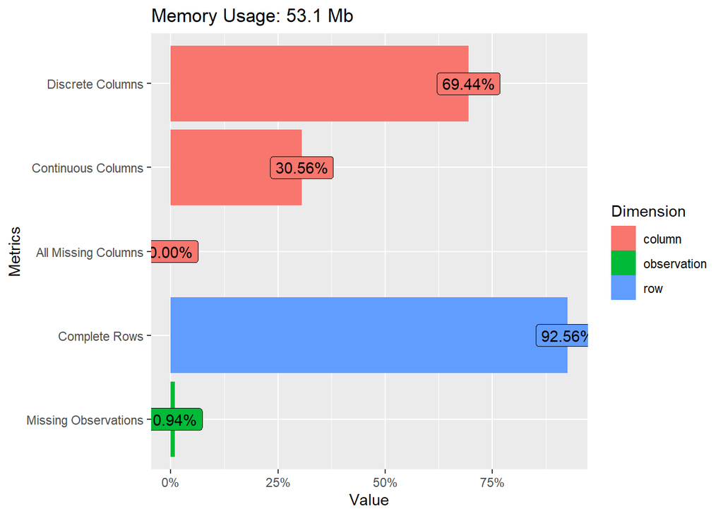

```r
plot_intro(AllTheData)
```

## 3.1 Missing values

Since missing values can create problems, it is important to look at the missing profiles.

The following plot shows the missing profile for each feature in the data set.

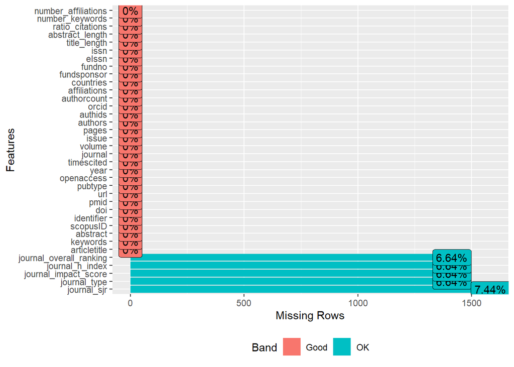

```r
# plot the missing data
plot_missing(AllTheData)
```

From the chart, journal-related data are the most often missed, which the highest value being the journal SJR index (~7.44% missing values).

## 3.2 Distributions

### 3.2.1 Bar charts

Next, visualizing the distributions of the discrete features in the data set is a neccessary step.

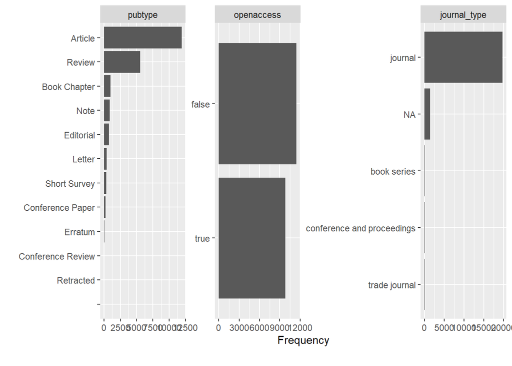

```r
plot_bar(AllTheData)
```

### 3.2.2 Histograms

Let’s visualize distributions for the continuous features.

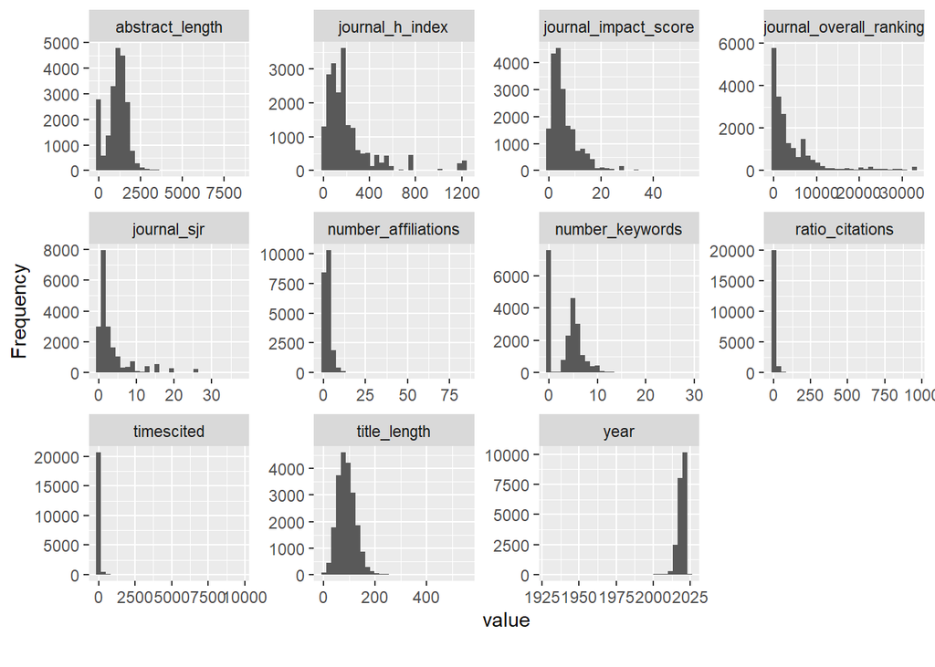

```r
plot_histogram(AllTheData)
```

## 3.3 Correlation Analysis

To visualize correlation heatmap for all non-missing features:

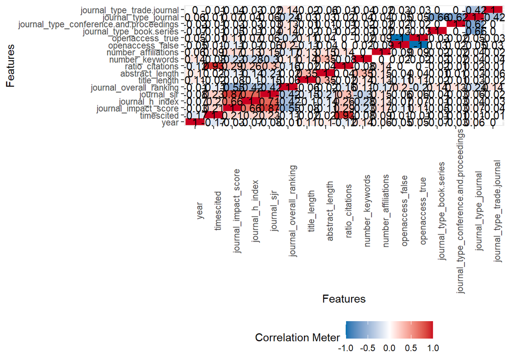

```r
plot_correlation(na.omit(AllTheData), maxcat = 5L)
```

```r
# plot_correlation(AllTheData, maxcat = 5L)
```

## 3.4 Principal Component Analysis

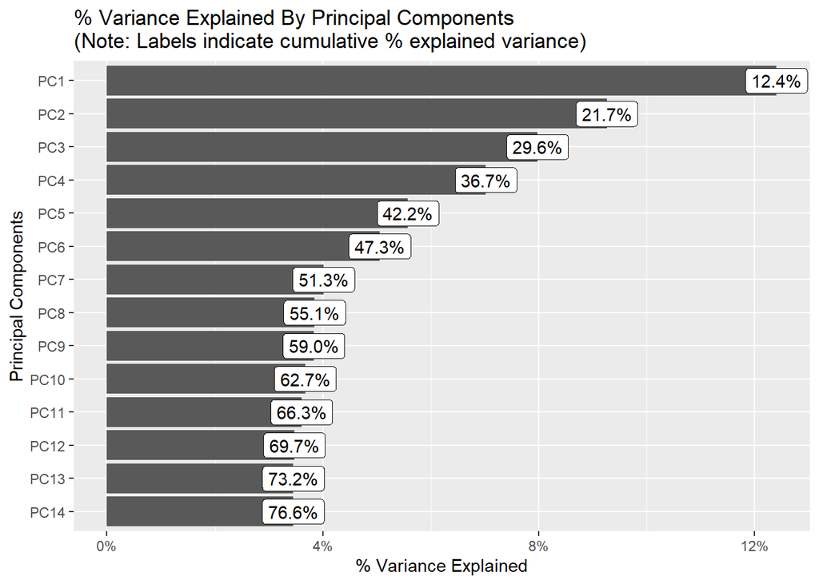

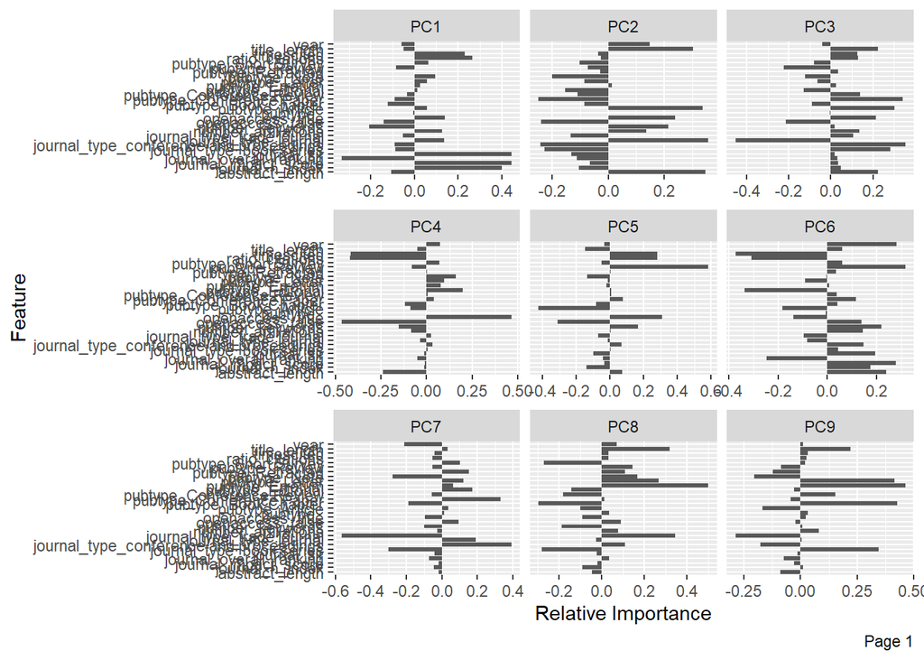

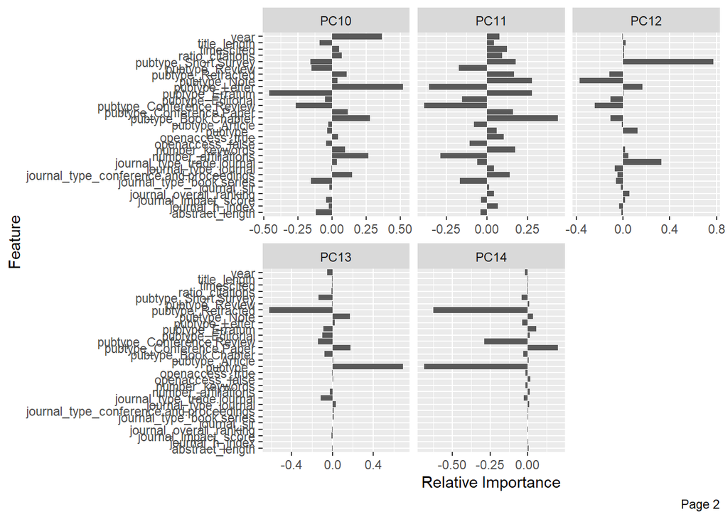

```r
plot_prcomp(na.omit(AllTheData))
```

# 4 Generating subset focused on technologies

It is time to create a dataset focused on the main gene/genome editing technologies identified.

```r
# reading the Excel file generated from Mynd containing the categorization on technologies and the recency
MyndInfo <- read_excel("./Mynd-Technologies_All.xlsx",sheet = "Technologies")
```

Then, the data frame containing the information from Mynd can be appended to the full data frame.

```r
# merge two data frames by ID
TechnologyData <- merge(AllTheData,MyndInfo,by="identifier")
```

Let’s make a subset for the relevant parameters:

```r
# select only the relevant parameters
TechnologyData_Subset <- subset(TechnologyData, select = c("identifier", "pubtype", "openaccess", "year", "timescited", "authorcount",  "journal_impact_score", "journal_h_index",  "journal_sjr",  "journal_overall_ranking", "title_length", "abstract_length", "ratio_citations", "number_keywords", "number_affiliations", "technology", "tech_recency_corrected"))
```

Let’s see how much data is missing now:

```r
# check features of the data set
introduce(TechnologyData_Subset)
```

```
##   rows columns discrete_columns continuous_columns all_missing_columns
## 1 5447      17                5                 12                   0
##   total_missing_values complete_rows total_observations memory_usage
## 1                 1519          5014              92599      1074544
```

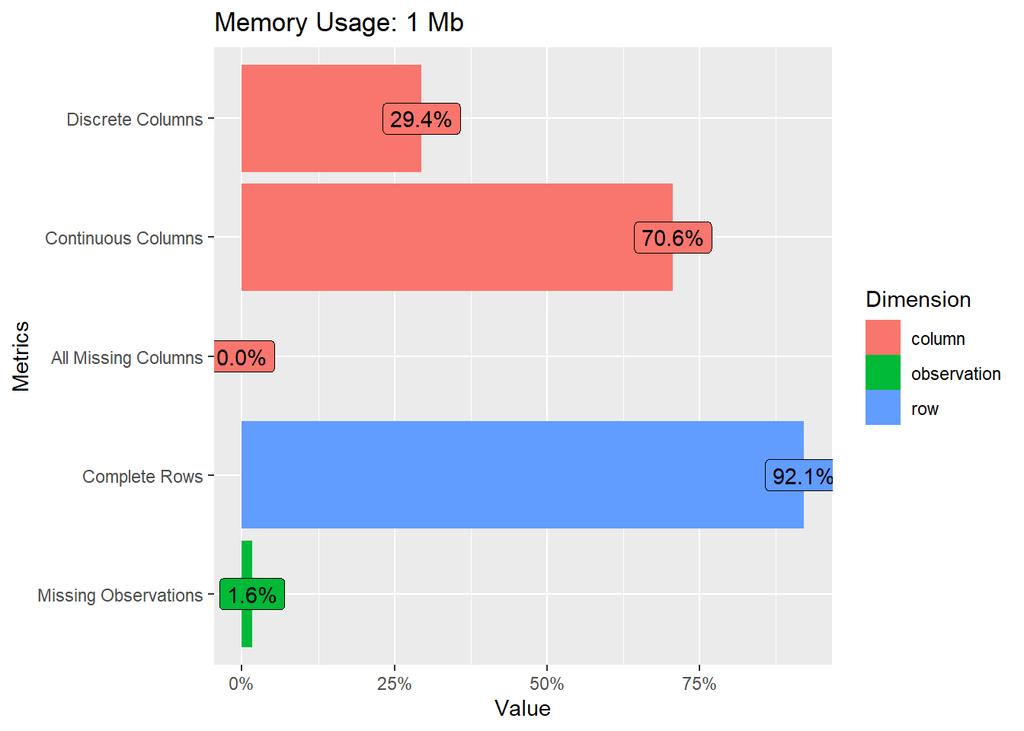

```r
plot_intro(TechnologyData_Subset)
```

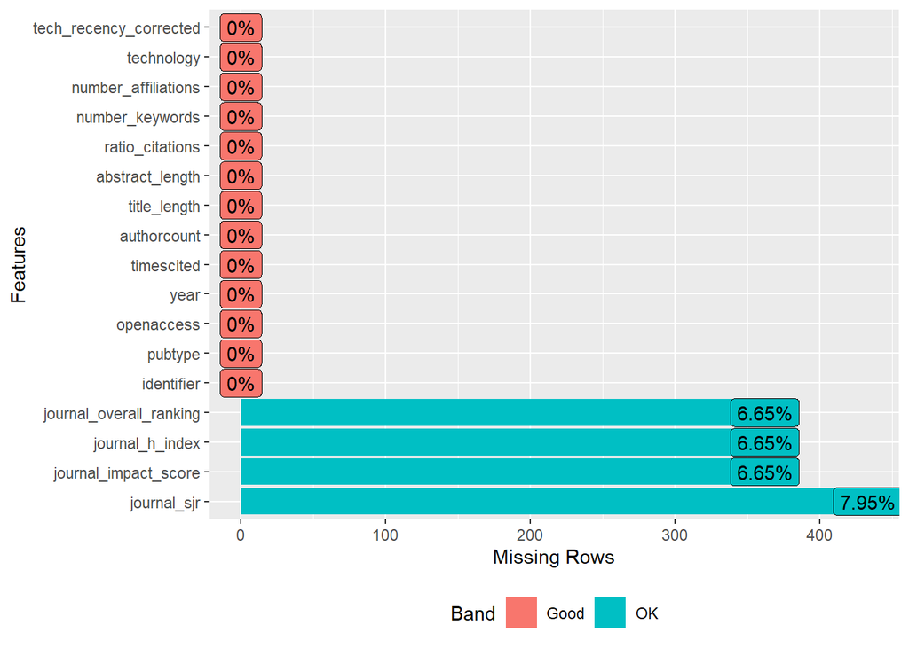

```r
# plot the missing data
plot_missing(TechnologyData_Subset)
```

For practical reasons, in the context of this project all of the NAs in the working subset are removed.

```r
# omit NAs in the subset
TechnologyData_Subset <- na.omit(TechnologyData_Subset)

# set the author count as numeric and other parameters as factors
TechnologyData_Subset$authorcount <- as.numeric(TechnologyData_Subset$authorcount)
TechnologyData_Subset$pubtype <- as.factor(TechnologyData_Subset$pubtype)
TechnologyData_Subset$openaccess <- as.factor(TechnologyData_Subset$openaccess)
TechnologyData_Subset$technology <- as.factor(TechnologyData_Subset$technology)
TechnologyData_Subset$tech_recency_corrected <- as.factor(TechnologyData_Subset$tech_recency_corrected)
```

Let’s look at the type of data for each parameter in the technology subset:

```r
# type of data for each parameter
str(TechnologyData_Subset)
```

```
## 'data.frame':    5014 obs. of  17 variables:
##  $ identifier             : chr  "SCOPUS_ID:23744462771" "SCOPUS_ID:27744530147" "SCOPUS_ID:34447319080" "SCOPUS_ID:35948946526" ...
##  $ pubtype                : Factor w/ 10 levels "Article","Book Chapter",..: 1 1 1 1 9 1 10 1 1 1 ...
##  $ openaccess             : Factor w/ 2 levels "false","true": 1 2 1 1 1 1 1 2 1 2 ...
##  $ year                   : num  2005 2005 2007 2007 2008 ...
##  $ timescited             : num  100 345 799 726 41 817 0 117 53 330 ...
##  $ authorcount            : num  5 6 13 12 3 23 3 3 3 5 ...
##  $ journal_impact_score   : num  3.31 16.48 15.13 15.13 3.52 ...
##  $ journal_h_index        : num  263 537 445 445 89 445 9 174 269 297 ...
##  $ journal_sjr            : num  0.998 9.008 15.358 15.358 0.603 ...
##  $ journal_overall_ranking: num  4393 96 32 32 8378 ...
##  $ title_length           : int  66 109 80 111 66 106 43 151 111 98 ...
##  $ abstract_length        : num  1074 1438 1003 1015 911 ...
##  $ ratio_citations        : num  5.53 19.06 49.63 45.09 2.71 ...
##  $ number_keywords        : num  7 0 0 0 5 0 0 0 4 0 ...
##  $ number_affiliations    : num  3 4 3 6 2 4 1 1 1 1 ...
##  $ technology             : Factor w/ 6 levels "CRISPR-Cas12",..: 6 6 6 6 6 6 6 6 6 6 ...
##  $ tech_recency_corrected : Factor w/ 2 levels "0","1": 1 1 1 1 1 1 1 1 1 1 ...
##  - attr(*, "na.action")= 'omit' Named int [1:433] 74 80 81 99 108 109 156 157 169 182 ...
##   ..- attr(*, "names")= chr [1:433] "74" "80" "81" "99" ...
```

Let’s look at the technologies present within the new data set:

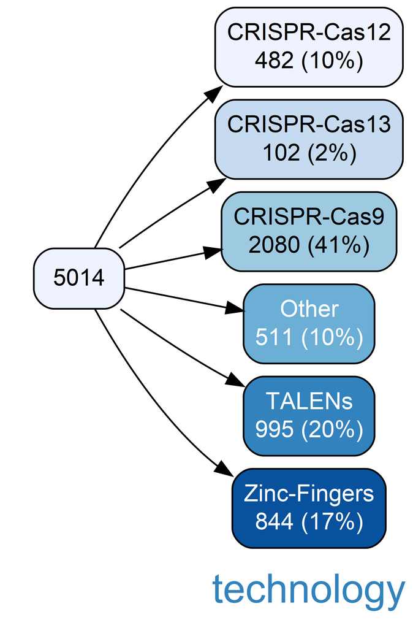

```r
vtree(TechnologyData_Subset, "technology", palette = 2)
```

## 4.1 Exploratory data analysis on the working subset

Finally, an exploratory data analysis is run on the technology subset generated.

### 4.1.1 Distributions

### 4.1.2 Bar charts

Next, visualizing the distributions of the discrete features in the data set is a necessary step.

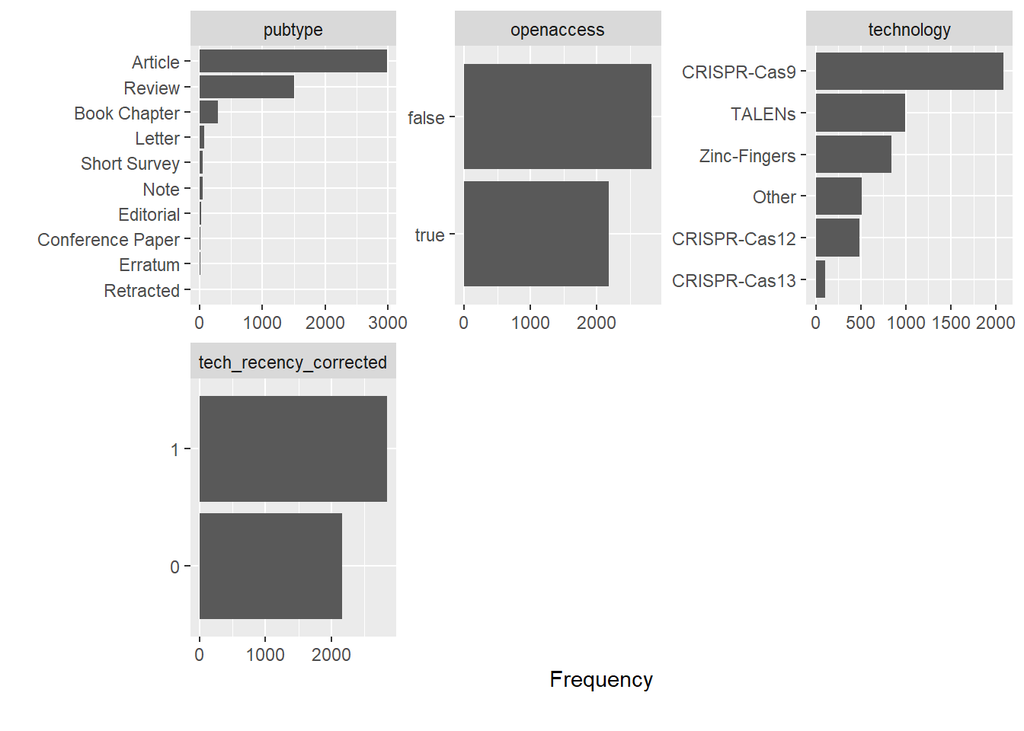

```r
plot_bar(TechnologyData_Subset)
```

### 4.1.3 Histograms

Let’s visualize distributions for the continuous features.

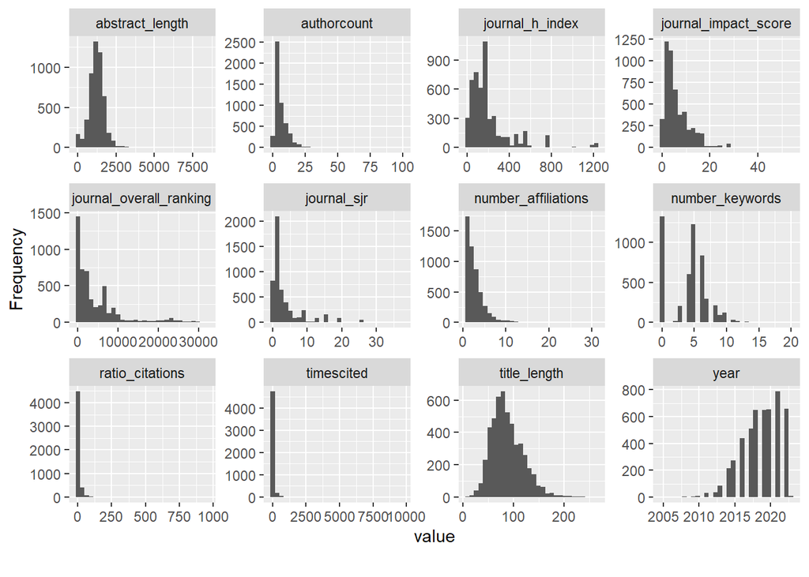

```r
plot_histogram(TechnologyData_Subset)
```

### 4.1.4 Univariate analysis for variables of interest

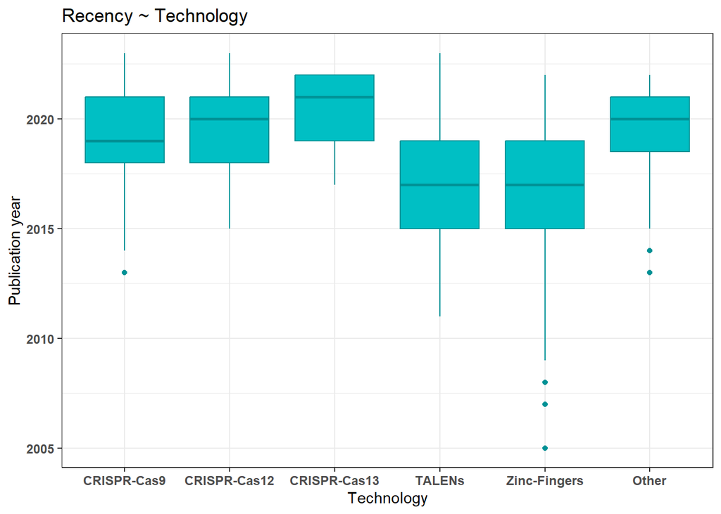

```r
correct_order_tech <- c("CRISPR-Cas9", "CRISPR-Cas12", "CRISPR-Cas13",
            "TALENs", "Zinc-Fingers", "Other")

p <- ggplot(TechnologyData_Subset, aes(x = factor(technology, correct_order_tech), y=year)) +
  geom_boxplot(fill='#00BFC4', color='#009296') +
  labs(x = 'Technology') +
  ggtitle("Recency ~ Technology ") +
  theme_bw() +
  theme(axis.text.x = element_text(face = 'bold', size = 9),
        axis.text.y = element_text(face = 'bold', size = 9)) +
  guides(fill=guide_legend(title="Recency")) + labs(y = "Publication year")

p
```

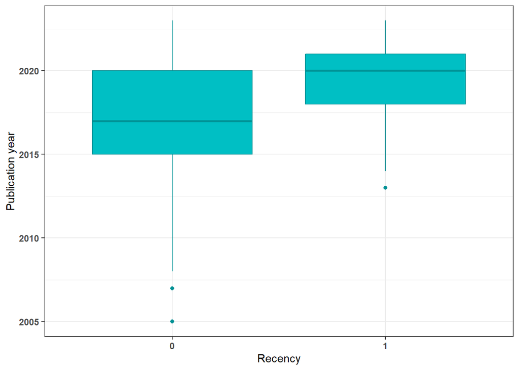

```r
q <- ggplot(TechnologyData_Subset, aes(x = tech_recency_corrected, y=year)) +
  geom_boxplot(fill='#00BFC4', color='#009296') +
  labs(x = 'Recency') +
  theme_bw() +
  theme(axis.text.x = element_text(face = 'bold', size = 9),
        axis.text.y = element_text(face = 'bold', size = 9)) + labs(y = "Publication year")

q
```

### 4.1.5 Bivariate analysis for variables of interest

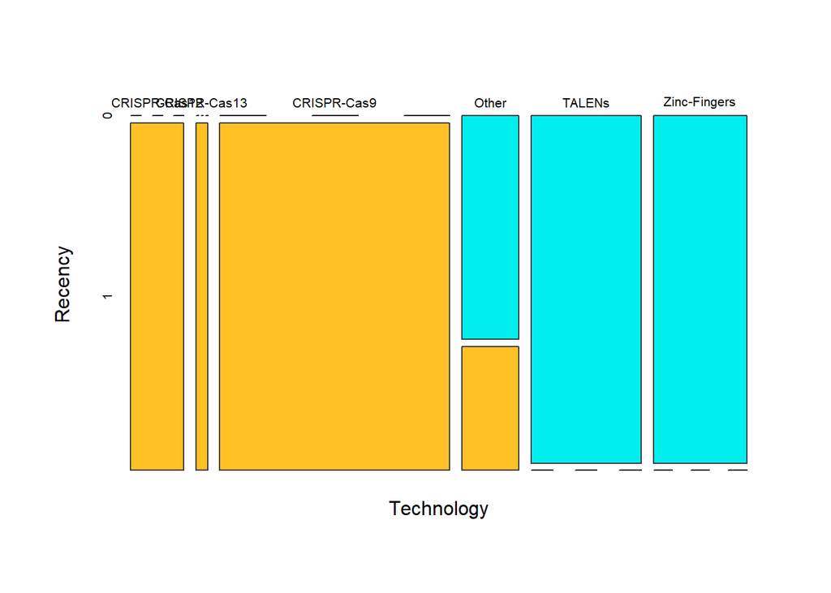

```
##    Cell Contents
## |-------------------------|
## |                   Count |
## |         Expected Values |
## |          Column Percent |
## |           Total Percent |
## |                Residual |
## |-------------------------|
##
## ======================================================================================
##             TechnologyData_Subset$technology
## TcD_S$__    CRISPR-C   CRISPR-C   CRISPR-C      Other     TALENs   Znc-Fngr      Total
## --------------------------------------------------------------------------------------
## 0                 0          0          0        329        995        844       2168
##               208.4       44.1      899.4      221.0      430.2      364.9
##                 0.0%       0.0%       0.0%      64.4%     100.0%     100.0%
##                 0.0%       0.0%       0.0%       6.6%      19.8%      16.8%
##            -208.412    -44.104   -899.370    108.049    564.773    479.063
## --------------------------------------------------------------------------------------
## 1               482        102       2080        182          0          0       2846
##               273.6       57.9     1180.6      290.0      564.8      479.1
##               100.0%     100.0%     100.0%      35.6%       0.0%       0.0%
##                 9.6%       2.0%      41.5%       3.6%       0.0%       0.0%
##             208.412     44.104    899.370   -108.049   -564.773   -479.063
## --------------------------------------------------------------------------------------
## Total           482        102       2080        511        995        844       5014
##                 9.6%       2.0%      41.5%      10.2%      19.8%      16.8%
## ======================================================================================
```

```r
crosstab(TechnologyData_Subset$tech_recency_corrected, TechnologyData_Subset$technology,
         expected = TRUE,
         prop.c = TRUE,
         prop.t = TRUE,
         resid = TRUE,
         format = "SPSS",
         percent = TRUE,
         xlab = "Technology",
         ylab = "Recency",
         plot = TRUE,
         col=c("cyan2","goldenrod1"),
         border="gray23")
```

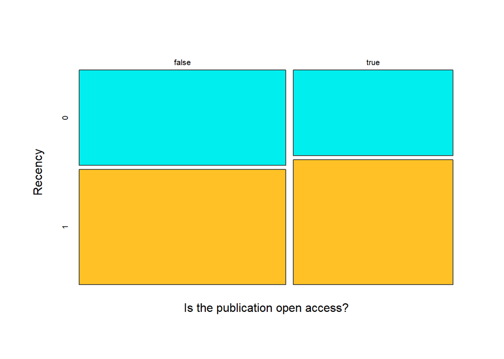

```
##    Cell Contents
## |-------------------------|
## |                   Count |
## |         Expected Values |
## |          Column Percent |
## |           Total Percent |
## |                Residual |
## |-------------------------|
##
## =========================================================================
##                                                 TechnologyData_Subset$openaccess
## TechnologyData_Subset$tech_recency_corrected      false      true   Total
## -------------------------------------------------------------------------
## 0                                                 1280       888    2168
##                                                 1222.8     945.2
##                                                   45.3%     40.6%
##                                                   25.5%     17.7%
##                                                 57.203   -57.203
## -------------------------------------------------------------------------
## 1                                                 1548      1298    2846
##                                                 1605.2    1240.8
##                                                   54.7%     59.4%
##                                                   30.9%     25.9%
##                                                -57.203    57.203
## -------------------------------------------------------------------------
## Total                                             2828      2186    5014
##                                                   56.4%     43.6%
## =========================================================================
```

```r
crosstab(TechnologyData_Subset$tech_recency_corrected, TechnologyData_Subset$openaccess,
         expected = TRUE,
         prop.c = TRUE,
         prop.t = TRUE,
         resid = TRUE,
         format = "SPSS",
         percent = TRUE,
         xlab = "Is the publication open access?",
         ylab = "Recency",
         plot = TRUE,
         col=c("cyan2","goldenrod1"),
         border="gray23")
```

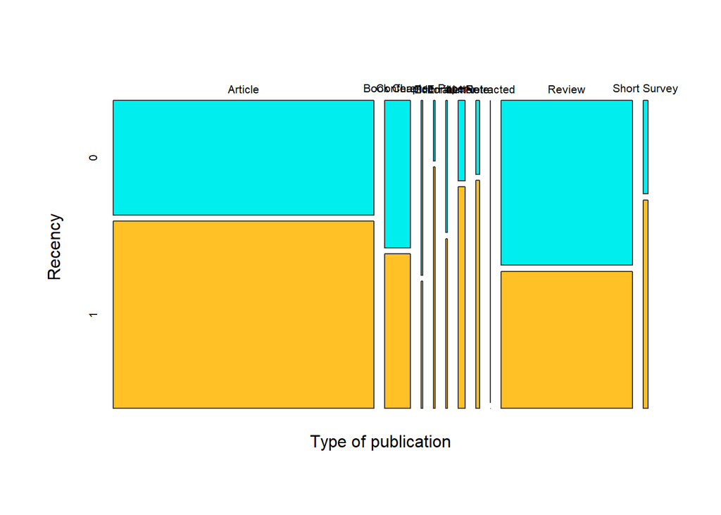

```
##    Cell Contents
## |-------------------------|
## |                   Count |
## |         Expected Values |
## |          Column Percent |
## |           Total Percent |
## |                Residual |
## |-------------------------|
##
## ==================================================================================================================================
##             TechnologyData_Subset$pubtype
## TcD_S$__     Article   Bk Chptr   Cnfrnc P   Editoril    Erratum     Letter       Note   Retractd     Review   Shrt Srv      Total
## ----------------------------------------------------------------------------------------------------------------------------------
## 0              1132        145         11          4          7         21         11          1        819         17       2168
##              1289.0      128.4        8.2        8.6        6.9       34.2       19.5        0.4      649.0       23.8
##                38.0%      48.8%      57.9%      20.0%      43.8%      26.6%      24.4%     100.0%      54.6%      30.9%
##                22.6%       2.9%       0.2%       0.1%       0.1%       0.4%       0.2%       0.0%      16.3%       0.3%
##            -156.953     16.580      2.785     -4.648      0.082    -13.159     -8.458      0.568    169.984     -6.781
## ----------------------------------------------------------------------------------------------------------------------------------
## 1              1849        152          8         16          9         58         34          0        682         38       2846
##              1692.0      168.6       10.8       11.4        9.1       44.8       25.5        0.6      852.0       31.2
##                62.0%      51.2%      42.1%      80.0%      56.2%      73.4%      75.6%       0.0%      45.4%      69.1%
##                36.9%       3.0%       0.2%       0.3%       0.2%       1.2%       0.7%       0.0%      13.6%       0.8%
##             156.953    -16.580     -2.785      4.648     -0.082     13.159      8.458     -0.568   -169.984      6.781
## ----------------------------------------------------------------------------------------------------------------------------------
## Total          2981        297         19         20         16         79         45          1       1501         55       5014
##                59.5%       5.9%       0.4%       0.4%       0.3%       1.6%       0.9%       0.0%      29.9%       1.1%
## ==================================================================================================================================
```

```r
crosstab(TechnologyData_Subset$tech_recency_corrected, TechnologyData_Subset$pubtype,
         expected = TRUE,
         prop.c = TRUE,
         prop.t = TRUE,
         resid = TRUE,
         format = "SPSS",
         percent = TRUE,
         xlab = "Type of publication",
         ylab = "Recency",
         plot = TRUE,
         col=c("cyan2","goldenrod1"),
         border="gray23")
```

### 4.1.6 Correlation Analysis

To visualize correlation heatmap for all non-missing features:

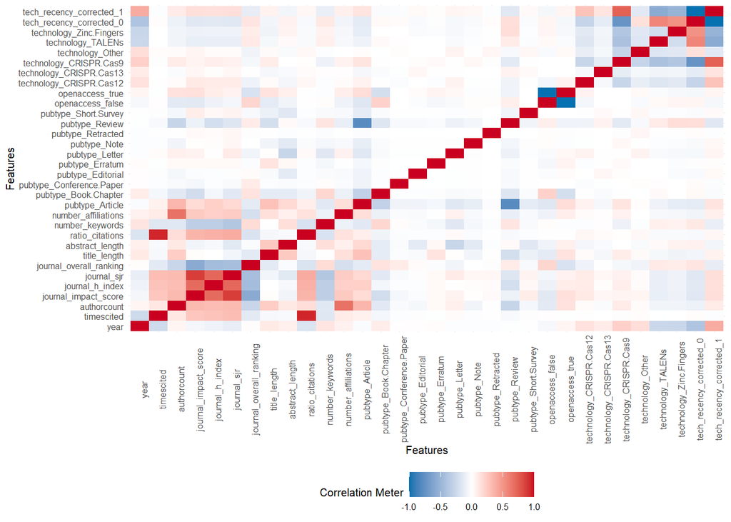

```r
plot_correlation(na.omit(TechnologyData_Subset), type="all", maxcat = 15L, ggtheme=theme_minimal(base_size = 7.5, base_family = ""))
```

Beyond that, it is important to show how the recency and the technology variables are correlated:

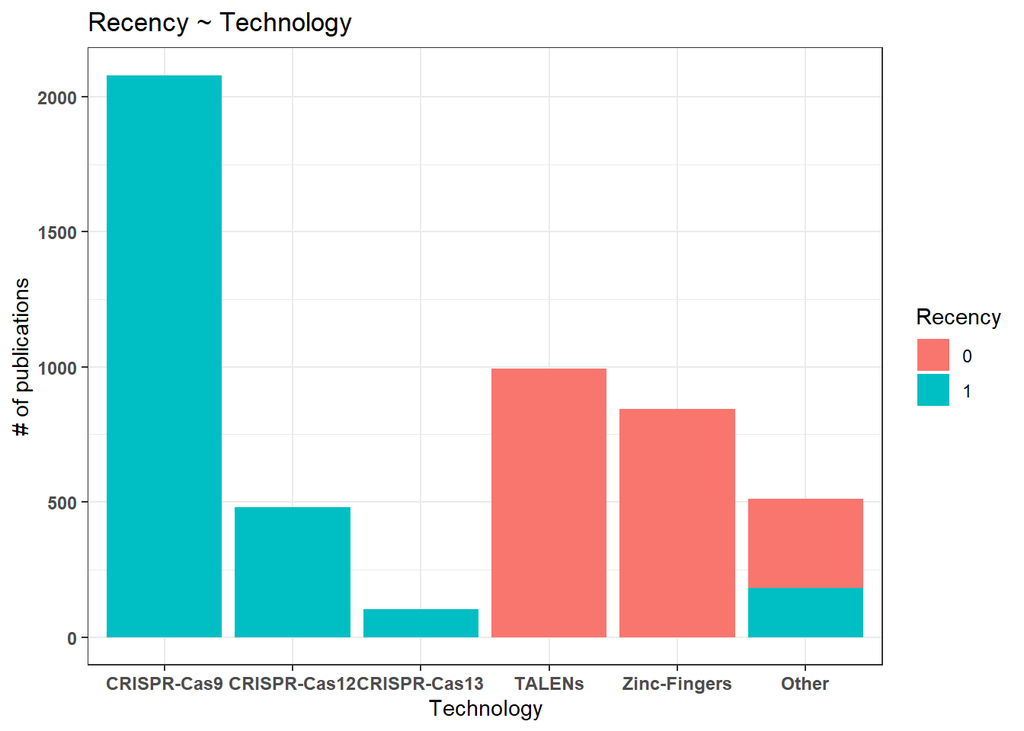

```r
# ggplot(TechnologyData_Subset) +
#   geom_bar(aes(x = technology,
#                    fill = tech_recency_corrected)) +
#   labs(x = 'Technology') +
#   ggtitle("Recency ~ Technology ") +
#   theme_bw() +
#   theme(axis.text.x = element_text(face = 'bold', size = 9),
#         axis.text.y = element_text(face = 'bold', size = 9)) +
#   guides(fill=guide_legend(title="Recency")) + labs(y = "# of publications")

correct_order_tech <- c("CRISPR-Cas9", "CRISPR-Cas12", "CRISPR-Cas13",
            "TALENs", "Zinc-Fingers", "Other")



ggplot(TechnologyData_Subset) +
  geom_bar(aes(x = factor(technology, correct_order_tech),
                   fill = tech_recency_corrected)) +
  labs(x = 'Technology') +
  ggtitle("Recency ~ Technology ") +
  theme_bw() +
  theme(axis.text.x = element_text(face = 'bold', size = 9),
        axis.text.y = element_text(face = 'bold', size = 9)) +
  guides(fill=guide_legend(title="Recency")) + labs(y = "# of publications")
```

### 4.1.7 Principal Component Analysis

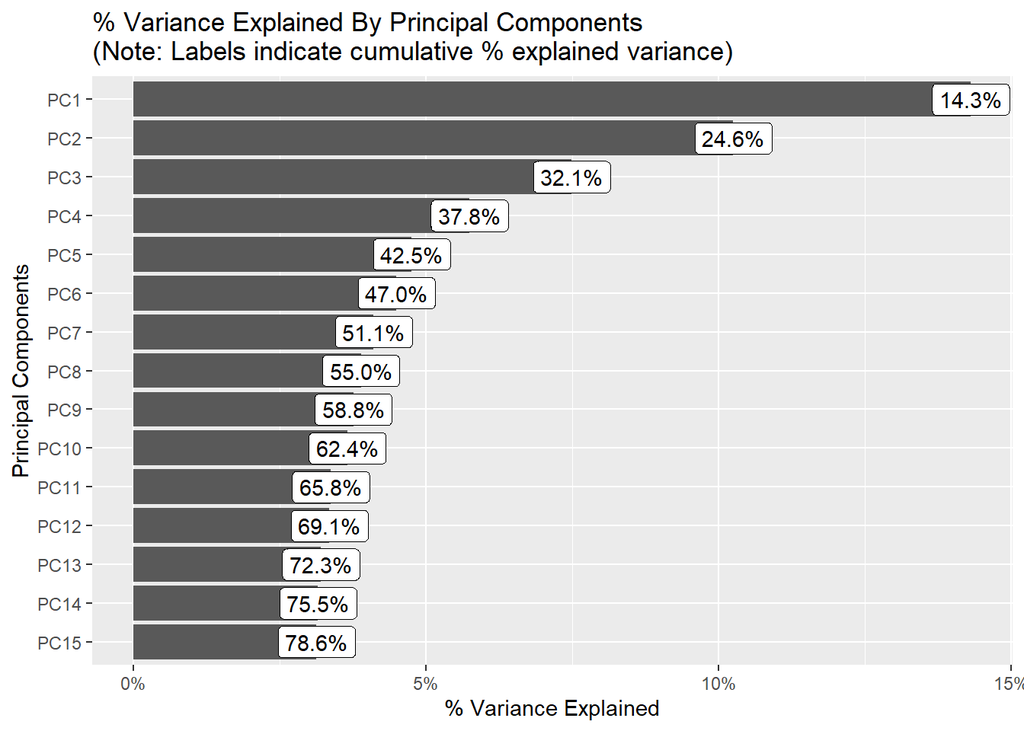

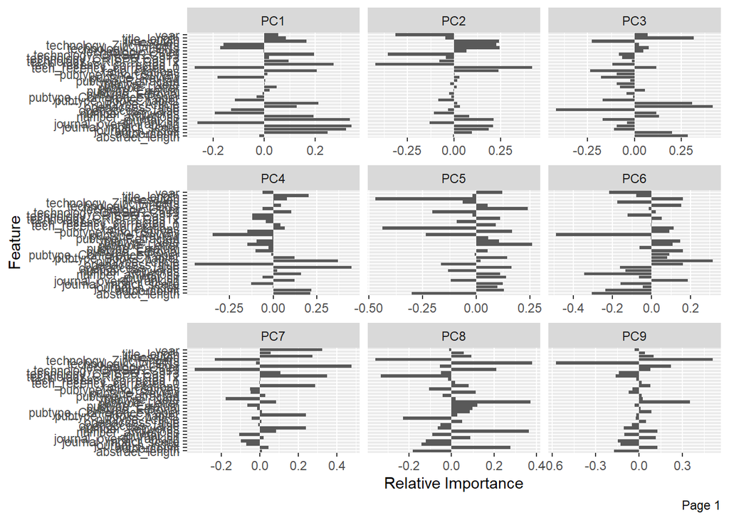

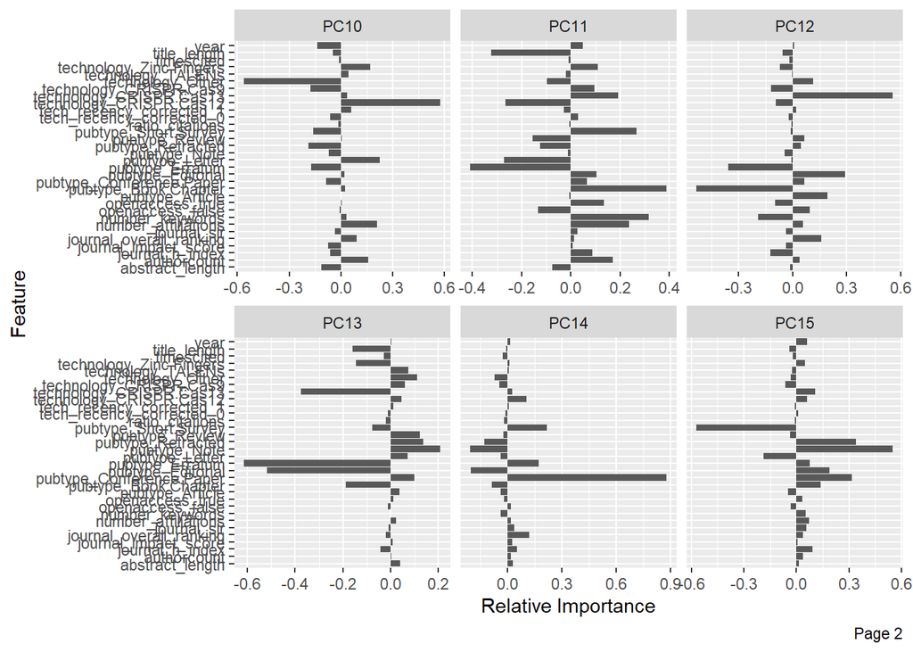

```r
plot_prcomp(na.omit(TechnologyData_Subset))
```

As shown in the analysis, the fact that 15 principal components explain around 80% of the variance means that it is not possible to rank these components in order of importance. In other words, it seems that all of them are equally important and therefore, all of them need to be considered in further steps.

Now it is time to adjust the supervised learning methods to the data set.

# 5 Forecasting trends through supervised learning algorithms

## 5.1 Separating between training and testing data sets

Before applying the supervised learning algorithms on the final data set, the latter has to be divided in two parts: one that will serve as a training for the model, and the other one, which will serve to test the models’ precision and fit.

```r
# we set a random seed
set.seed(123)

# exclude the identifiers from the dataset, since they are no longer needed
TechnologyData_Subset <- subset(TechnologyData_Subset, select = -c(1))

# divide the data set in train and test with the "sample" function
data_partition<-sample(c(rep(0, 0.8*nrow(TechnologyData_Subset)),rep(1, 0.2*nrow(TechnologyData_Subset))))
data_train<-TechnologyData_Subset[data_partition == 0,]
data_test<-TechnologyData_Subset[data_partition == 1,]

# remove any further NAs just in case
data_train <- na.omit(data_train)
data_test <- na.omit(data_test)
```

## 5.2 Classification and regression tree (CART)

First, we start adjusting a classification and regression tree.

```r
# https://www.statology.org/classification-and-regression-trees-in-r/
# https://www.statmethods.net/advstats/cart.html

# we set the seed
set.seed(123)

# step1: Begin with a small cp.
tree <- rpart(tech_recency_corrected~., data = data_train, method = "class",
              control = rpart.control(cp = 0.0001), usesurrogate=2, surrogatestyle=0)

# step2: Pick the tree size that minimizes misclassification rate (i.e. prediction error).
# Prediction error rate in training data = Root node error * rel error * 100%
# Prediction error rate in cross-validation = Root node error * xerror * 100%
# Hence we want the cp value (with a simpler tree) that minimizes the xerror.
printcp(tree)
```

```
##
## Classification tree:
## rpart(formula = tech_recency_corrected ~ ., data = data_train,
##     method = "class", control = rpart.control(cp = 1e-04), usesurrogate = 2,
##     surrogatestyle = 0)
##
## Variables actually used in tree construction:
##  [1] abstract_length         authorcount             journal_h_index
##  [4] journal_impact_score    journal_overall_ranking journal_sjr
##  [7] pubtype                 technology              title_length
## [10] year
##
## Root node error: 1742/4004 = 0.43506
##
## n= 4004
##
##          CP nsplit rel error   xerror      xstd
## 1 0.9104478      0  1.000000 1.000000 0.0180084
## 2 0.0106200      1  0.089552 0.089552 0.0070289
## 3 0.0017222      5  0.047072 0.053387 0.0054713
## 4 0.0010046     12  0.034443 0.062572 0.0059111
## 5 0.0001000     16  0.030425 0.064868 0.0060155
```

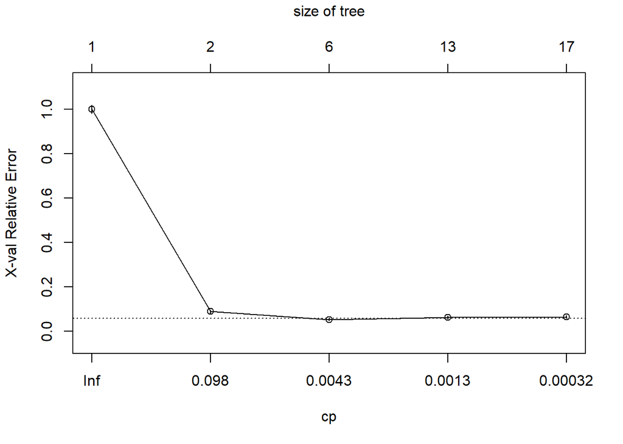

```r
plotcp(tree)
```

```r
# select the best tree
bestcp <- tree$cptable[which.min(tree$cptable[,"xerror"]),"CP"]

# step3: Prune the tree using the best cp.
tree.pruned <- prune(tree, cp = bestcp)
printcp(tree.pruned)
```

```
##
## Classification tree:
## rpart(formula = tech_recency_corrected ~ ., data = data_train,
##     method = "class", control = rpart.control(cp = 1e-04), usesurrogate = 2,
##     surrogatestyle = 0)
##
## Variables actually used in tree construction:
## [1] journal_sjr pubtype     technology  year
##
## Root node error: 1742/4004 = 0.43506
##
## n= 4004
##
##          CP nsplit rel error   xerror      xstd
## 1 0.9104478      0  1.000000 1.000000 0.0180084
## 2 0.0106200      1  0.089552 0.089552 0.0070289
## 3 0.0017222      5  0.047072 0.053387 0.0054713
```

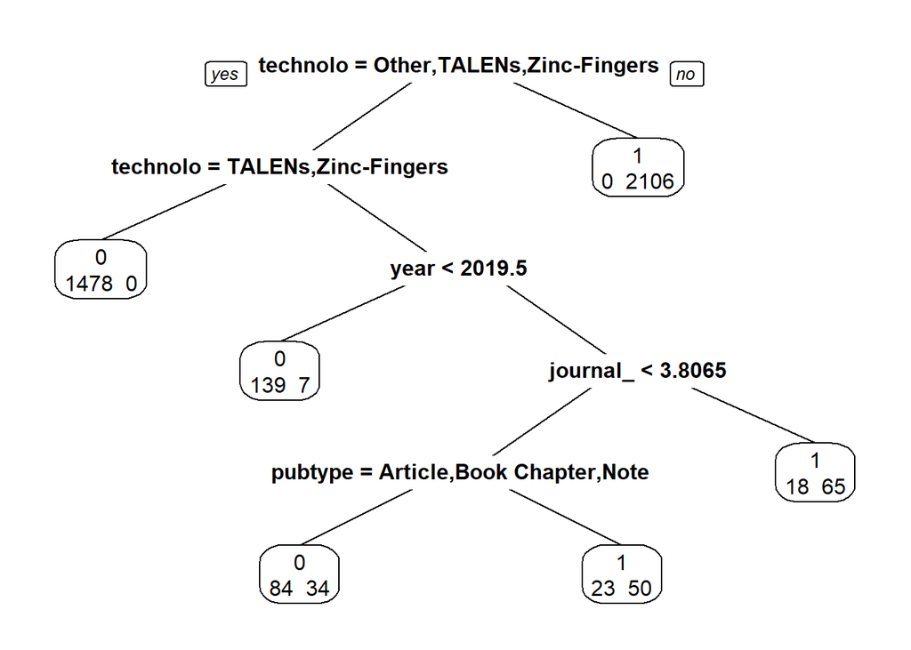

```r
# plot the pruned tree
prp(tree.pruned,
    faclen=0, #use full names for factor labels
    extra=1, #display number of obs. for each terminal node
    roundint=F, #don't round to integers in output
    digits=5) #display 5 decimal places in output
```

```r
# variable importance
tree.pruned$variable.importance
```

```
##              technology                    year                 pubtype
##            1772.1194805             496.9113643             228.6386013
##    journal_impact_score         journal_h_index             journal_sjr
##             147.9023260             126.6513371             123.5212577
##              timescited journal_overall_ranking         ratio_citations
##              16.3607348              13.6409508              11.1053830
##            title_length         abstract_length         number_keywords
##               3.4811270               2.8861440               2.6295809
##             authorcount
##               0.9727092
```

```r
summary(tree.pruned$variable.importance)
```

```
##      Min.   1st Qu.    Median      Mean   3rd Qu.      Max.
##    0.9727    3.4811   16.3607  226.6785  147.9023 1772.1195
```

The generated tree shows that the recency is intensely linked to the technology type, which is a good sign. This can clearly be visualized with a cross table:

```r
crosstable(TechnologyData_Subset, c("technology"), by="tech_recency_corrected")
```

```
## # A tibble: 6 × 5
##   .id        label      variable     `0`           `1`
##   <chr>      <chr>      <chr>        <chr>         <chr>
## 1 technology technology CRISPR-Cas12 0 (0%)        482 (100.00%)
## 2 technology technology CRISPR-Cas13 0 (0%)        102 (100.00%)
## 3 technology technology CRISPR-Cas9  0 (0%)        2080 (100.00%)
## 4 technology technology Other        329 (64.38%)  182 (35.62%)
## 5 technology technology TALENs       995 (100.00%) 0 (0%)
## 6 technology technology Zinc-Fingers 844 (100.00%) 0 (0%)
```

Let’s check the performance the CART model.

```r
# predict using the test data
predictions_CART <- predict(tree.pruned, data_test)


# save the predictions of the CART
pred_CART <- vector()

for(i in 1:nrow(predictions_CART)){
  if  (predictions_CART[i] >= 0.5){
    pred_CART[i] = 0
  } else {
    pred_CART[i] = 1
  }
}
pred_CART <- factor(pred_CART, levels = c(0, 1))

# compute model accuracy
accuracy_CART <- mean(pred_CART == data_test$tech_recency_corrected)

# generate a confusion matrix
CM_CART <- confusionMatrix(pred_CART, data_test$tech_recency_corrected, mode = "everything")
CM_CART
```

```
## Confusion Matrix and Statistics
##
##           Reference
## Prediction   0   1
##          0 412   6
##          1  10 574
##
##                Accuracy : 0.984
##                  95% CI : (0.9742, 0.9908)
##     No Information Rate : 0.5788
##     P-Value [Acc > NIR] : <2e-16
##
##                   Kappa : 0.9672
##
##  Mcnemar's Test P-Value : 0.4533
##
##             Sensitivity : 0.9763
##             Specificity : 0.9897
##          Pos Pred Value : 0.9856
##          Neg Pred Value : 0.9829
##               Precision : 0.9856
##                  Recall : 0.9763
##                      F1 : 0.9810
##              Prevalence : 0.4212
##          Detection Rate : 0.4112
##    Detection Prevalence : 0.4172
##       Balanced Accuracy : 0.9830
##
##        'Positive' Class : 0
##
```

Let’s compute the CART model now without the technology variable.

```r
# we set the seed
set.seed(123)

# we make a new subset excluding the technology
data_train_notech <- subset(data_train, select = -c(15))
data_test_notech <- subset(data_test, select = -c(15))

# step1: Begin with a small cp.
tree_notech <- rpart(tech_recency_corrected~., data = data_train_notech, method = "class",
              control = rpart.control(cp = 0.0001), usesurrogate=2, surrogatestyle=0)

# step2: Pick the tree size that minimizes misclassification rate (i.e. prediction error).
# Prediction error rate in training data = Root node error * rel error * 100%
# Prediction error rate in cross-validation = Root node error * xerror * 100%
# Hence we want the cp value (with a simpler tree) that minimizes the xerror.
printcp(tree_notech)
```

```
##
## Classification tree:
## rpart(formula = tech_recency_corrected ~ ., data = data_train_notech,
##     method = "class", control = rpart.control(cp = 1e-04), usesurrogate = 2,
##     surrogatestyle = 0)
##
## Variables actually used in tree construction:
##  [1] abstract_length         authorcount             journal_h_index
##  [4] journal_impact_score    journal_overall_ranking journal_sjr
##  [7] number_affiliations     number_keywords         openaccess
## [10] pubtype                 ratio_citations         timescited
## [13] title_length            year
##
## Root node error: 1742/4004 = 0.43506
##
```

[output cut: 30 more lines]

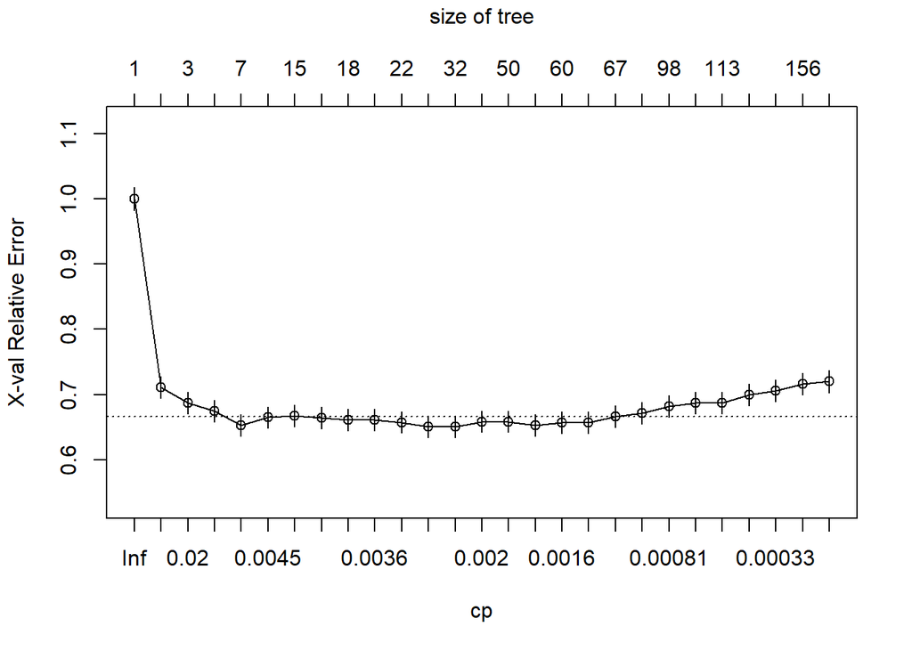

```r
plotcp(tree_notech)
```

```r
# select the best tree
bestcp_notech <- tree_notech$cptable[which.min(tree_notech$cptable[,"xerror"]),"CP"]

# step3: Prune the tree using the best cp.
tree.pruned_notech <- prune(tree_notech, cp = bestcp_notech)
printcp(tree.pruned_notech)
```

```
##
## Classification tree:
## rpart(formula = tech_recency_corrected ~ ., data = data_train_notech,
##     method = "class", control = rpart.control(cp = 1e-04), usesurrogate = 2,
##     surrogatestyle = 0)
##
## Variables actually used in tree construction:
##  [1] abstract_length     authorcount         journal_h_index
##  [4] journal_sjr         number_affiliations number_keywords
##  [7] pubtype             ratio_citations     title_length
## [10] year
##
## Root node error: 1742/4004 = 0.43506
##
## n= 4004
##
##           CP nsplit rel error  xerror     xstd
## 1  0.2887486      0   1.00000 1.00000 0.018008
## 2  0.0304248      1   0.71125 0.71125 0.016791
## 3  0.0132032      2   0.68083 0.68657 0.016625
## 4  0.0088021      3   0.66762 0.67451 0.016540
## 5  0.0045924      6   0.64122 0.65270 0.016379
## 6  0.0044011      9   0.62744 0.66475 0.016469
## 7  0.0043054     14   0.60390 0.66762 0.016490
## 8  0.0040184     16   0.59529 0.66418 0.016465
## 9  0.0037313     17   0.59127 0.66131 0.016444
## 10 0.0034443     19   0.58381 0.66073 0.016440
## 11 0.0022962     21   0.57692 0.65729 0.016414
## 12 0.0021049     22   0.57463 0.65040 0.016362
```

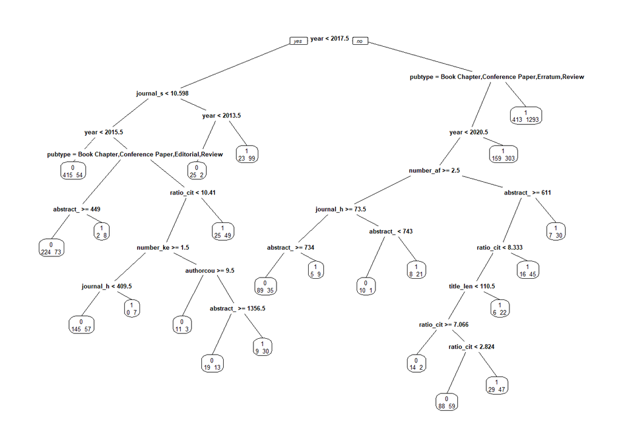

```r
# plot the pruned tree
prp(tree.pruned_notech,
    faclen=0, #use full names for factor labels
    extra=1, #display number of obs. for each terminal node
    roundint=F, #don't round to integers in output
    digits=5) #display 5 decimal places in output
```

```r
# variable importance
tree.pruned_notech$variable.importance
```

```
##                    year              timescited             journal_sjr
##             325.3878949              98.8650410              65.5940145
## journal_overall_ranking                 pubtype         ratio_citations
##              63.4068857              55.5359966              53.9257869
##    journal_impact_score         journal_h_index         abstract_length
##              38.3004774              31.9278002              25.9417210
##             authorcount            title_length     number_affiliations
##              19.0351142              15.6174321              10.0436732
##         number_keywords              openaccess
##               9.3380205               0.8684698
```

```r
summary(tree.pruned_notech$variable.importance)
```

```
##     Min.  1st Qu.   Median     Mean  3rd Qu.     Max.
##   0.8685  16.4719  35.1141  58.1277  61.4392 325.3879
```

Let’s check the performance the CART model without the technology variable.

```r
# predict using the test data
predictions_CART_notech <- predict(tree.pruned_notech, data_test_notech)


# save the predictions of the CART
pred_CART_notech <- vector()

for(i in 1:nrow(predictions_CART_notech)){
  if  (predictions_CART_notech[i] >= 0.5){
    pred_CART_notech[i] = 0
  } else {
    pred_CART_notech[i] = 1
  }
}
pred_CART_notech <- factor(pred_CART_notech, levels = c(0, 1))

# compute model accuracy
accuracy_CART_notech <- mean(pred_CART_notech == data_test_notech$tech_recency_corrected)

# generate a confusion matrix
CM_CART_notech <- confusionMatrix(pred_CART_notech, data_test_notech$tech_recency_corrected, mode = "everything")
CM_CART_notech
```

```
## Confusion Matrix and Statistics
##
##           Reference
## Prediction   0   1
##          0 234 103
##          1 188 477
##
##                Accuracy : 0.7096
##                  95% CI : (0.6804, 0.7375)
##     No Information Rate : 0.5788
##     P-Value [Acc > NIR] : < 2.2e-16
##
##                   Kappa : 0.3875
##
##  Mcnemar's Test P-Value : 8.472e-07
##
##             Sensitivity : 0.5545
##             Specificity : 0.8224
##          Pos Pred Value : 0.6944
##          Neg Pred Value : 0.7173
##               Precision : 0.6944
##                  Recall : 0.5545
##                      F1 : 0.6166
##              Prevalence : 0.4212
##          Detection Rate : 0.2335
##    Detection Prevalence : 0.3363
##       Balanced Accuracy : 0.6885
##
##        'Positive' Class : 0
##
```

## 5.3 Random Forest

Let’s adjust a random forest model.

```r
# set a random seed
set.seed(123)

# compute the random forest model
rf <- randomForest(tech_recency_corrected~., data=data_train, importance=TRUE)
rf
```

```
##
## Call:
##  randomForest(formula = tech_recency_corrected ~ ., data = data_train,      importance = TRUE)
##                Type of random forest: classification
##                      Number of trees: 500
## No. of variables tried at each split: 3
##
##         OOB estimate of  error rate: 2.5%
## Confusion matrix:
##      0    1 class.error
## 0 1703   39  0.02238806
## 1   61 2201  0.02696729
```

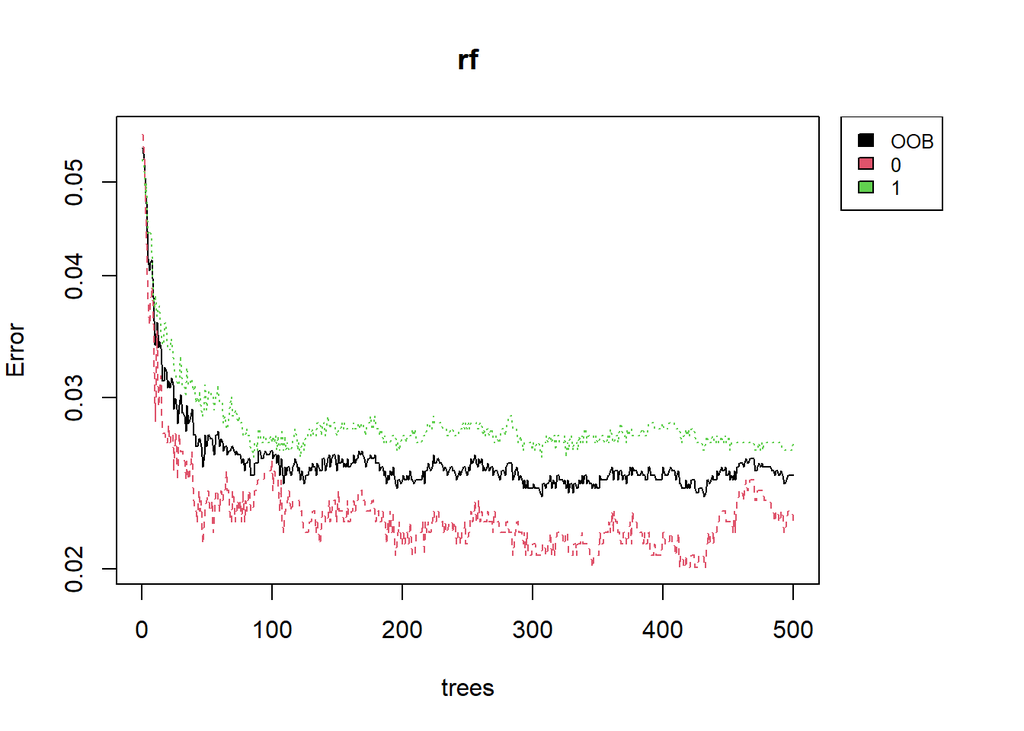

```r
# plot the model
layout(matrix(c(1,2),nrow=1),
       width=c(4,1))
par(mar=c(5,4,4,0)) #No margin on the right side
plot(rf, log="y")
par(mar=c(5,0,4,2)) #No margin on the left side
plot(c(0,1),type="n", axes=F, xlab="", ylab="")
legend("top", colnames(rf$err.rate),col=1:3,cex=0.8,fill=1:3)
```

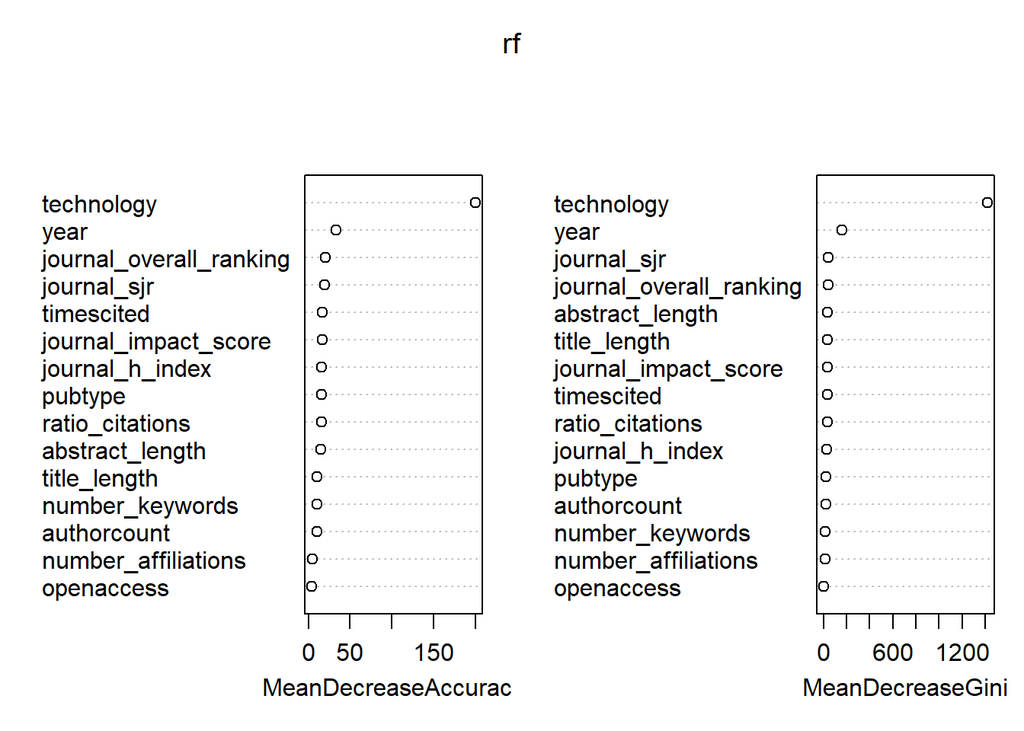

```r
# plot variable importance
varImpPlot(rf)
```

Let’s check the performance of the random forest obtained.

```r
# save the predictions of the random forest
predictions_rf <- predict(rf, data_test, type="prob")
pred_rf <- vector()

for(i in 1:nrow(predictions_rf)){
  if  (predictions_rf[i] >= 0.5){
    pred_rf[i] = 0
  } else {
    pred_rf[i] = 1
  }
}
pred_rf <- factor(pred_rf, levels = c(0, 1))

# generate a confusion matrix
CM_rf <- confusionMatrix(pred_rf, data_test$tech_recency_corrected, mode = "everything")
CM_rf
```

```
## Confusion Matrix and Statistics
##
##           Reference
## Prediction   0   1
##          0 414  12
##          1   8 568
##
##                Accuracy : 0.98
##                  95% CI : (0.9693, 0.9878)
##     No Information Rate : 0.5788
##     P-Value [Acc > NIR] : <2e-16
##
##                   Kappa : 0.9591
##
##  Mcnemar's Test P-Value : 0.5023
##
##             Sensitivity : 0.9810
##             Specificity : 0.9793
##          Pos Pred Value : 0.9718
##          Neg Pred Value : 0.9861
##               Precision : 0.9718
##                  Recall : 0.9810
##                      F1 : 0.9764
##              Prevalence : 0.4212
##          Detection Rate : 0.4132
##    Detection Prevalence : 0.4251
##       Balanced Accuracy : 0.9802
##
##        'Positive' Class : 0
##
```

Let’s calculate the random forest without the variable technology to see if the important variables remain the same.

```r
# set a random seed
set.seed(123)

# compute the random forest model
rf_notech <- randomForest(tech_recency_corrected~., data=data_train_notech, importance=TRUE)
rf_notech
```

```
##
## Call:
##  randomForest(formula = tech_recency_corrected ~ ., data = data_train_notech,      importance = TRUE)
##                Type of random forest: classification
##                      Number of trees: 500
## No. of variables tried at each split: 3
##
##         OOB estimate of  error rate: 24.9%
## Confusion matrix:
##      0    1 class.error
## 0 1167  575   0.3300804
## 1  422 1840   0.1865606
```

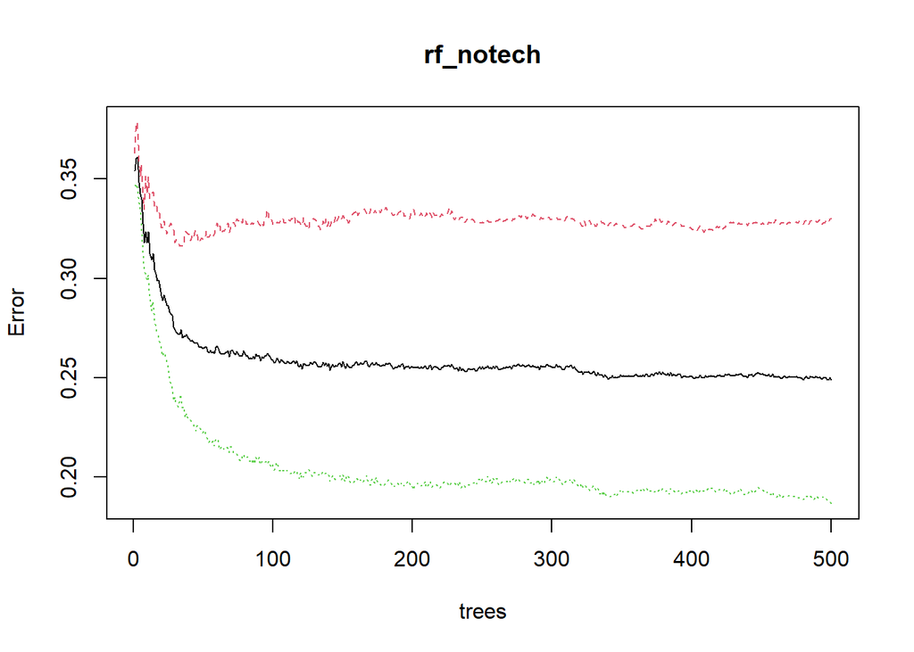

```r
# plot the model
plot(rf_notech)
```

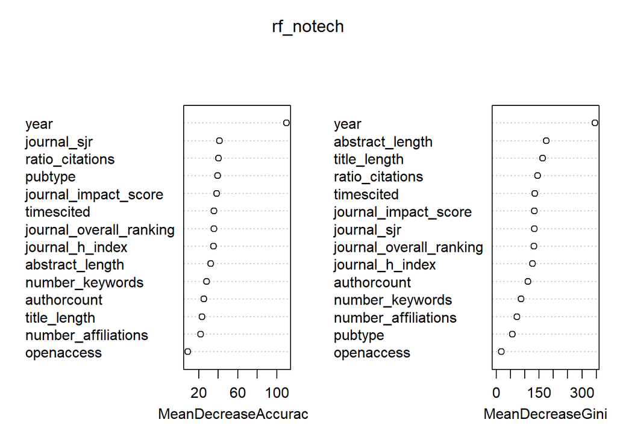

```r
# plot variable importance
varImpPlot(rf_notech)
```

```r
importance(rf_notech, type=1)
```

```
##                         MeanDecreaseAccuracy
## pubtype                            39.455476
## openaccess                          8.427386
## year                              110.343062
## timescited                         35.483548
## authorcount                        24.977902
## journal_impact_score               38.297585
## journal_h_index                    35.224801
## journal_sjr                        41.218377
## journal_overall_ranking            35.330667
## title_length                       23.315495
## abstract_length                    32.135409
## ratio_citations                    40.228688
## number_keywords                    28.064462
## number_affiliations                21.929317
```

```r
importance(rf_notech, type=2)
```

```
##                         MeanDecreaseGini
## pubtype                         57.61467
## openaccess                      18.80914
## year                           346.21478
## timescited                     135.60467
## authorcount                    110.71148
## journal_impact_score           133.97021
## journal_h_index                127.02295
## journal_sjr                    133.82345
## journal_overall_ranking        131.63050
## title_length                   162.00363
## abstract_length                175.20664
## ratio_citations                144.91209
## number_keywords                 87.42529
## number_affiliations             72.94180
```

Let’s check the performance of the random forest without the technology variable.

```r
# save the predictions of the random forest
predictions_rf_notech <- predict(rf_notech, data_test_notech, type="prob")
pred_rf_notech <- vector()

for(i in 1:nrow(predictions_rf_notech)){
  if  (predictions_rf_notech[i] >= 0.5){
    pred_rf_notech[i] = 0
  } else {
    pred_rf_notech[i] = 1
  }
}
pred_rf_notech <- factor(pred_rf_notech, levels = c(0, 1))

# generate a confusion matrix
CM_rf_notech <- confusionMatrix(pred_rf_notech, data_test$tech_recency_corrected, mode = "everything")
CM_rf_notech
```

```
## Confusion Matrix and Statistics
##
##           Reference
## Prediction   0   1
##          0 294 112
##          1 128 468
##
##                Accuracy : 0.7605
##                  95% CI : (0.7328, 0.7866)
##     No Information Rate : 0.5788
##     P-Value [Acc > NIR] : <2e-16
##
##                   Kappa : 0.5062
##
##  Mcnemar's Test P-Value : 0.3329
##
##             Sensitivity : 0.6967
##             Specificity : 0.8069
##          Pos Pred Value : 0.7241
##          Neg Pred Value : 0.7852
##               Precision : 0.7241
##                  Recall : 0.6967
##                      F1 : 0.7101
##              Prevalence : 0.4212
##          Detection Rate : 0.2934
##    Detection Prevalence : 0.4052
##       Balanced Accuracy : 0.7518
##
##        'Positive' Class : 0
##
```

## 5.4 Suport Vector Machine (SVM)

In this section, a SVM model is implemented. Different kernels are tried for this purpose.

### 5.4.1 Linear kernel

```r
# set a random seed
set.seed(123)

# build the SVM model
svm_linear <- ksvm(tech_recency_corrected~., data = data_train, kernel = "vanilladot")
# show the result of the SVM model
svm_linear
```

```
## Support Vector Machine object of class "ksvm"
##
## SV type: C-svc  (classification)
##  parameter : cost C = 1
##
## Linear (vanilla) kernel function.
##
## Number of Support Vectors : 288
##
## Objective Function Value : -239.7624
## Training error : 0.02048
```

Let’s check the performance of the SVM model with linear kernel:

```r
# predict using the test data
predictions_SVMlin <- predict(svm_linear, data_test)

# compute model accuracy
accuracy_SVMlin <- mean(predictions_SVMlin == data_test$tech_recency_corrected)

# generate a confusion matrix
CM_SVMlin <- confusionMatrix(predictions_SVMlin, data_test$tech_recency_corrected, mode = "everything")
CM_SVMlin
```

```
## Confusion Matrix and Statistics
##
##           Reference
## Prediction   0   1
##          0 415   8
##          1   7 572
##
##                Accuracy : 0.985
##                  95% CI : (0.9754, 0.9916)
##     No Information Rate : 0.5788
##     P-Value [Acc > NIR] : <2e-16
##
##                   Kappa : 0.9693
##
##  Mcnemar's Test P-Value : 1
##
##             Sensitivity : 0.9834
##             Specificity : 0.9862
##          Pos Pred Value : 0.9811
##          Neg Pred Value : 0.9879
##               Precision : 0.9811
##                  Recall : 0.9834
##                      F1 : 0.9822
##              Prevalence : 0.4212
##          Detection Rate : 0.4142
##    Detection Prevalence : 0.4222
##       Balanced Accuracy : 0.9848
##
##        'Positive' Class : 0
##
```

The accuracy obtained is very high (>0.9), it could either be a sign of a good model or a sign that the data set is very biased in a way. In this case, we know that the variable technology is strongly correlated with the recency. For this reason, a first step to understand this would be removing it from the model and checking what the obtained result. This is done below:

```r
# set a random seed
set.seed(123)

# build the SVM model
svm_linear_notech <- ksvm(tech_recency_corrected~., data = data_train_notech, kernel = "vanilladot")
# show the result of the SVM model
svm_linear_notech
```

```
## Support Vector Machine object of class "ksvm"
##
## SV type: C-svc  (classification)
##  parameter : cost C = 1
##
## Linear (vanilla) kernel function.
##
## Number of Support Vectors : 2577
##
## Objective Function Value : -2558.988
## Training error : 0.278222
```

```r
# predict using the test data
predictions_SVMlin_notech <- predict(svm_linear_notech, data_test_notech)

# compute model accuracy
accuracy_SVMlin_notech <- mean(predictions_SVMlin_notech == data_test_notech$tech_recency_corrected)

# generate a confusion matrix
CM_SVMlin_notech <- confusionMatrix(predictions_SVMlin_notech, data_test$tech_recency_corrected, mode = "everything")
CM_SVMlin_notech
```

```
## Confusion Matrix and Statistics
##
##           Reference
## Prediction   0   1
##          0 265 107
##          1 157 473
##
##                Accuracy : 0.7365
##                  95% CI : (0.7081, 0.7636)
##     No Information Rate : 0.5788
##     P-Value [Acc > NIR] : < 2.2e-16
##
##                   Kappa : 0.4508
##
##  Mcnemar's Test P-Value : 0.002564
##
##             Sensitivity : 0.6280
##             Specificity : 0.8155
##          Pos Pred Value : 0.7124
##          Neg Pred Value : 0.7508
##               Precision : 0.7124
##                  Recall : 0.6280
##                      F1 : 0.6675
##              Prevalence : 0.4212
##          Detection Rate : 0.2645
##    Detection Prevalence : 0.3713
##       Balanced Accuracy : 0.7217
##
##        'Positive' Class : 0
##
```

### 5.4.2 Gaussian kernel

```r
# set a random seed
set.seed(123)

# build the SVM model
svm_gauss <- ksvm(tech_recency_corrected~., data = data_train, kernel = "rbfdot")

# show the result of the SVM model
svm_gauss
```

```
## Support Vector Machine object of class "ksvm"
##
## SV type: C-svc  (classification)
##  parameter : cost C = 1
##
## Gaussian Radial Basis kernel function.
##  Hyperparameter : sigma =  0.075798429346348
##
## Number of Support Vectors : 860
##
## Objective Function Value : -456.7996
## Training error : 0.02048
```

Let’s check the performance of the SVM model with Gaussian kernel:

```r
# predict using the test data
predictions_SVMgauss <- predict(svm_gauss, data_test)

# compute model accuracy
accuracy_SVMgauss <- mean(predictions_SVMgauss == data_test$tech_recency_corrected)

# generate a confusion matrix
CM_SVMgauss <- confusionMatrix(predictions_SVMgauss, data_test$tech_recency_corrected, mode = "everything")
CM_SVMgauss
```

```
## Confusion Matrix and Statistics
##
##           Reference
## Prediction   0   1
##          0 412  11
##          1  10 569
##
##                Accuracy : 0.979
##                  95% CI : (0.9681, 0.987)
##     No Information Rate : 0.5788
##     P-Value [Acc > NIR] : <2e-16
##
##                   Kappa : 0.957
##
##  Mcnemar's Test P-Value : 1
##
##             Sensitivity : 0.9763
##             Specificity : 0.9810
##          Pos Pred Value : 0.9740
##          Neg Pred Value : 0.9827
##               Precision : 0.9740
##                  Recall : 0.9763
##                      F1 : 0.9751
##              Prevalence : 0.4212
##          Detection Rate : 0.4112
##    Detection Prevalence : 0.4222
##       Balanced Accuracy : 0.9787
##
##        'Positive' Class : 0
##
```

The accuracy obtained is very high (>0.9), it could either be a sign of a good model or a sign that the data set is very biased in a way. In this case, we know that the variable technology is strongly correlated with the recency. For this reason, a first step to understand this would be removing it from the model and checking what the obtained result. This is done below:

```r
# set a random seed
set.seed(123)

# build the SVM model
svm_gauss_notech <- ksvm(tech_recency_corrected~., data = data_train_notech, kernel = "rbfdot")

# show the result of the SVM model
svm_gauss_notech
```

```
## Support Vector Machine object of class "ksvm"
##
## SV type: C-svc  (classification)
##  parameter : cost C = 1
##
## Gaussian Radial Basis kernel function.
##  Hyperparameter : sigma =  0.088433407747602
##
## Number of Support Vectors : 2664
##
## Objective Function Value : -2341.128
## Training error : 0.241758
```

```r
# predict using the test data
predictions_SVMgauss_notech <- predict(svm_gauss_notech, data_test_notech)

# compute model accuracy
accuracy_SVMgauss_notech <- mean(predictions_SVMgauss_notech == data_test_notech$tech_recency_corrected)

# generate a confusion matrix
CM_SVMgauss_notech <- confusionMatrix(predictions_SVMgauss_notech, data_test$tech_recency_corrected, mode = "everything")
CM_SVMgauss_notech
```

```
## Confusion Matrix and Statistics
##
##           Reference
## Prediction   0   1
##          0 242  93
##          1 180 487
##
##                Accuracy : 0.7275
##                  95% CI : (0.6988, 0.7549)
##     No Information Rate : 0.5788
##     P-Value [Acc > NIR] : < 2.2e-16
##
##                   Kappa : 0.4251
##
##  Mcnemar's Test P-Value : 1.94e-07
##
##             Sensitivity : 0.5735
##             Specificity : 0.8397
##          Pos Pred Value : 0.7224
##          Neg Pred Value : 0.7301
##               Precision : 0.7224
##                  Recall : 0.5735
##                      F1 : 0.6394
##              Prevalence : 0.4212
##          Detection Rate : 0.2415
##    Detection Prevalence : 0.3343
##       Balanced Accuracy : 0.7066
##
##        'Positive' Class : 0
##
```

### 5.4.3 Polynomial kernel

```r
# set a random seed
set.seed(123)

# build the SVM model
svm_polynom <- ksvm(tech_recency_corrected~., data = data_train, kernel = "polydot")
# show the result of the SVM model
svm_polynom
```

```
## Support Vector Machine object of class "ksvm"
##
## SV type: C-svc  (classification)
##  parameter : cost C = 1
##
## Polynomial kernel function.
##  Hyperparameters : degree =  1  scale =  1  offset =  1
##
## Number of Support Vectors : 288
##
## Objective Function Value : -239.7624
## Training error : 0.02048
```

Let’s check the performance of the SVM model with polynomial kernel:

```r
# predict using the test data
predictions_SVMpolynom <- predict(svm_polynom, data_test)

# compute model accuracy
accuracy_SVMpolynom <- mean(predictions_SVMpolynom == data_test$tech_recency_corrected)

# generate a confusion matrix
CM_SVMpolynom <- confusionMatrix(predictions_SVMpolynom, data_test$tech_recency_corrected)
CM_SVMpolynom
```

```
## Confusion Matrix and Statistics
##
##           Reference
## Prediction   0   1
##          0 415   8
##          1   7 572
##
##                Accuracy : 0.985
##                  95% CI : (0.9754, 0.9916)
##     No Information Rate : 0.5788
##     P-Value [Acc > NIR] : <2e-16
##
##                   Kappa : 0.9693
##
##  Mcnemar's Test P-Value : 1
##
##             Sensitivity : 0.9834
##             Specificity : 0.9862
##          Pos Pred Value : 0.9811
##          Neg Pred Value : 0.9879
##              Prevalence : 0.4212
##          Detection Rate : 0.4142
##    Detection Prevalence : 0.4222
##       Balanced Accuracy : 0.9848
##
##        'Positive' Class : 0
##
```

The accuracy obtained is very high (>0.9), it could either be a sign of a good model or a sign that the data set is very biased in a way. In this case, we know that the variable technology is strongly correlated with the recency. For this reason, a first step to understand this would be removing it from the model and checking what the obtained result. This is done below:

```r
# set a random seed
set.seed(123)

# build the SVM model
svm_polynom_notech <- ksvm(tech_recency_corrected~., data = data_train_notech, kernel = "polydot")
# show the result of the SVM model
svm_polynom_notech
```

```
## Support Vector Machine object of class "ksvm"
##
## SV type: C-svc  (classification)
##  parameter : cost C = 1
##
## Polynomial kernel function.
##  Hyperparameters : degree =  1  scale =  1  offset =  1
##
## Number of Support Vectors : 2579
##
## Objective Function Value : -2558.988
## Training error : 0.277972
```

```r
# predict using the test data
predictions_SVMpolynom_notech <- predict(svm_polynom_notech, data_test_notech)

# compute model accuracy
accuracy_SVMpolynom_notech <- mean(predictions_SVMpolynom_notech == data_test_notech$tech_recency_corrected)

# generate a confusion matrix
CM_SVMpolynom_notech <- confusionMatrix(predictions_SVMpolynom_notech, data_test$tech_recency_corrected)
CM_SVMpolynom_notech
```

```
## Confusion Matrix and Statistics
##
##           Reference
## Prediction   0   1
##          0 265 107
##          1 157 473
##
##                Accuracy : 0.7365
##                  95% CI : (0.7081, 0.7636)
##     No Information Rate : 0.5788
##     P-Value [Acc > NIR] : < 2.2e-16
##
##                   Kappa : 0.4508
##
##  Mcnemar's Test P-Value : 0.002564
##
##             Sensitivity : 0.6280
##             Specificity : 0.8155
##          Pos Pred Value : 0.7124
##          Neg Pred Value : 0.7508
##              Prevalence : 0.4212
##          Detection Rate : 0.2645
##    Detection Prevalence : 0.3713
##       Balanced Accuracy : 0.7217
##
##        'Positive' Class : 0
##
```

## 5.5 Logistic Regression

### 5.5.1 Complete logistic regression

Let’s adjust a logistic regression model.

```r
# set a random seed
set.seed(123)

# compute logistic regression
logreg <- glm(tech_recency_corrected~., data = data_train, family = "binomial")

# show a summary and the coefficients of the model obtained
summary(logreg)
```

```
##
## Call:
## glm(formula = tech_recency_corrected ~ ., family = "binomial",
##     data = data_train)
##
## Deviance Residuals:
##    Min      1Q  Median      3Q     Max
## -2.854   0.000   0.000   0.000   3.748
##
## Coefficients:
##                           Estimate Std. Error z value Pr(>|z|)
## (Intercept)             -1.782e+03  8.173e+02  -2.180 0.029257 *
## pubtypeBook Chapter     -1.387e+00  7.766e-01  -1.786 0.074024 .
## pubtypeConference Paper -2.716e+01  1.628e+07   0.000 0.999999
## pubtypeEditorial         2.117e+01  8.434e+03   0.003 0.997997
## pubtypeErratum          -4.582e+01  2.373e+07   0.000 0.999998
## pubtypeLetter            5.071e-01  8.741e-01   0.580 0.561786
## pubtypeNote              4.195e-01  1.451e+00   0.289 0.772405
## pubtypeReview            1.413e+00  3.762e-01   3.757 0.000172 ***
## pubtypeShort Survey      8.432e-01  1.013e+00   0.833 0.404993
## openaccesstrue           6.448e-01  3.058e-01   2.109 0.034971 *
## year                     9.013e-01  1.491e-01   6.044  1.5e-09 ***
## timescited              -2.380e-02  1.493e-02  -1.594 0.110973
## authorcount             -1.126e-01  4.731e-02  -2.379 0.017346 *
## journal_impact_score    -1.561e-01  7.243e-02  -2.156 0.031113 *
## journal_h_index          6.862e-04  1.138e-03   0.603 0.546669
## journal_sjr              2.644e-01  9.200e-02   2.875 0.004047 **
## journal_overall_ranking -7.252e-05  4.177e-05  -1.736 0.082580 .
## title_length            -7.373e-03  5.520e-03  -1.336 0.181616
## abstract_length         -2.425e-04  3.262e-04  -0.743 0.457196
## ratio_citations          1.180e-01  5.615e-02   2.101 0.035651 *
## number_keywords         -3.880e-03  6.252e-02  -0.062 0.950515
## number_affiliations      4.267e-02  9.335e-02   0.457 0.647624
## technologyCRISPR-Cas13  -1.031e+01  2.956e+04   0.000 0.999722
## technologyCRISPR-Cas9    5.923e+01  3.693e+03   0.016 0.987203
## technologyOther         -3.885e+01  7.556e+02  -0.051 0.958999
## technologyTALENs        -7.766e+01  1.195e+04  -0.006 0.994814
## technologyZinc-Fingers  -6.422e+01  1.103e+04  -0.006 0.995355
## ---
## Signif. codes:  0 '***' 0.001 '**' 0.01 '*' 0.05 '.' 0.1 ' ' 1
##
## (Dispersion parameter for binomial family taken to be 1)
##
##     Null deviance: 5483.00  on 4003  degrees of freedom
## Residual deviance:  332.42  on 3977  degrees of freedom
## AIC: 386.42
##
## Number of Fisher Scoring iterations: 25
```

```r
coef(logreg)
```

```
##             (Intercept)     pubtypeBook Chapter pubtypeConference Paper
##           -1.781754e+03           -1.387349e+00           -2.716479e+01
##        pubtypeEditorial          pubtypeErratum           pubtypeLetter
##            2.117049e+01           -4.581775e+01            5.071264e-01
##             pubtypeNote           pubtypeReview     pubtypeShort Survey
##            4.195350e-01            1.413272e+00            8.431526e-01
##          openaccesstrue                    year              timescited
##            6.447789e-01            9.012525e-01           -2.379915e-02
##             authorcount    journal_impact_score         journal_h_index
##           -1.125602e-01           -1.561228e-01            6.862110e-04
##             journal_sjr journal_overall_ranking            title_length
##            2.644418e-01           -7.251584e-05           -7.373271e-03
##         abstract_length         ratio_citations         number_keywords
##           -2.425124e-04            1.179699e-01           -3.880282e-03
##     number_affiliations  technologyCRISPR-Cas13   technologyCRISPR-Cas9
##            4.266556e-02           -1.030919e+01            5.923109e+01
##         technologyOther        technologyTALENs  technologyZinc-Fingers
##           -3.884762e+01           -7.765818e+01           -6.422124e+01
```

According to the results the following variables are significant in the logistic regression: “pubtypeReview”, “openaccesstrue”, “year”, “authorcount”, “journal-impact-score”, “journal-sjr” and “ratio_citations”.

Let’s check the performance of the logistic regression:

```r
# http://www.sthda.com/english/articles/36-classification-methods-essentials/151-logistic-regression-essentials-in-r/#multiple-logistic-regression

# exclude a retracted paper from the data_test subset
data_test2 <- subset(data_test,  pubtype != "Retracted")
data_test2_notech <- subset(data_test2, select = -c(15))

# predict using the test data
prob_logreg <- logreg %>% predict(data_test2, type="response")
pred_classes_logreg <- ifelse(prob_logreg> 0.5, "1", "0")
pred_classes_logreg  <- factor(pred_classes_logreg, levels = c(0, 1))

# compute model accuracy
accuracy_logreg <- mean(pred_classes_logreg == data_test2$tech_recency_corrected)

# generate a confusion matrix
CM_logreg <- confusionMatrix(pred_classes_logreg, data_test2$tech_recency_corrected, mode = "everything")
CM_logreg
```

```
## Confusion Matrix and Statistics
##
##           Reference
## Prediction   0   1
##          0 414   4
##          1   7 576
##
##                Accuracy : 0.989
##                  95% CI : (0.9804, 0.9945)
##     No Information Rate : 0.5794
##     P-Value [Acc > NIR] : <2e-16
##
##                   Kappa : 0.9774
##
##  Mcnemar's Test P-Value : 0.5465
##
##             Sensitivity : 0.9834
##             Specificity : 0.9931
##          Pos Pred Value : 0.9904
##          Neg Pred Value : 0.9880
##               Precision : 0.9904
##                  Recall : 0.9834
##                      F1 : 0.9869
##              Prevalence : 0.4206
##          Detection Rate : 0.4136
##    Detection Prevalence : 0.4176
##       Balanced Accuracy : 0.9882
##
##        'Positive' Class : 0
##
```

Let’s calculate the adjustment coefficient R^2 for the model and run a goodness-of-fit test.

```r
pR2(logreg)
```

```
## fitting null model for pseudo-r2
```

```
##           llh       llhNull            G2      McFadden          r2ML
##  -166.2100077 -2741.4995127  5150.5790100     0.9393726     0.7237250
##          r2CU
##     0.9704847
```

### 5.5.2 Stepwise logistic regression

Even though at first sight the model seems to be very good, it is somehow strange that the variable technology does not appear as significant, since we know it is very well correlated with the recency. For this reason, a stepwise approach is taken.

```r
# http://www.sthda.com/english/articles/36-classification-methods-essentials/150-stepwise-logistic-regression-essentials-in-r/
# https://ashutoshtripathi.com/2019/06/10/what-is-stepaic-in-r/

set.seed(123)
logreg_step <- logreg %>% stepAIC(trace = FALSE)
coef(logreg_step)
```

```
##             (Intercept)     pubtypeBook Chapter pubtypeConference Paper
##           -1.781415e+03           -1.263860e+00           -2.622424e+01
##        pubtypeEditorial          pubtypeErratum           pubtypeLetter
##            2.046711e+01           -4.381507e+01            7.562897e-01
##             pubtypeNote           pubtypeReview     pubtypeShort Survey
##            9.744720e-01            1.400280e+00            9.817884e-01
##          openaccesstrue                    year              timescited
##            6.453464e-01            9.006935e-01           -2.319159e-02
##             authorcount    journal_impact_score             journal_sjr
##           -1.057404e-01           -1.516988e-01            2.862837e-01
## journal_overall_ranking            title_length         ratio_citations
##           -7.558602e-05           -8.402536e-03            1.157850e-01
##  technologyCRISPR-Cas13   technologyCRISPR-Cas9         technologyOther
##           -1.059372e+01            5.645422e+01           -3.818325e+01
##        technologyTALENs  technologyZinc-Fingers
##           -7.507621e+01           -6.258701e+01
```

Let’s calculate the adjustment coefficient R^2 for the stepwise model and run a goodness-of-fit test.

```r
pR2(logreg_step)
```

```
## fitting null model for pseudo-r2
```

```
##           llh       llhNull            G2      McFadden          r2ML
##  -166.7568100 -2741.4995127  5149.4854054     0.9391731     0.7236495
##          r2CU
##     0.9703835
```

Once the stepwise model has been computed, its performance can be computed.

```r
# performance of stepwise logistic regression

# predict using the test data
prob_logreg_step <- logreg_step %>% predict(data_test2, type="response")
pred_classes_logreg_step <- ifelse(prob_logreg_step> 0.5, "1", "0")
pred_classes_logreg_step  <- factor(pred_classes_logreg_step, levels = c(0, 1))

# compute model accuracy
accuracy_logreg_step <- mean(pred_classes_logreg_step == data_test2$tech_recency_corrected)

# generate a confusion matrix
CM_logreg_step <- confusionMatrix(pred_classes_logreg_step, data_test2$tech_recency_corrected, mode = "everything")
CM_logreg_step
```

```
## Confusion Matrix and Statistics
##
##           Reference
## Prediction   0   1
##          0 414   5
##          1   7 575
##
##                Accuracy : 0.988
##                  95% CI : (0.9792, 0.9938)
##     No Information Rate : 0.5794
##     P-Value [Acc > NIR] : <2e-16
##
##                   Kappa : 0.9754
##
##  Mcnemar's Test P-Value : 0.7728
##
##             Sensitivity : 0.9834
##             Specificity : 0.9914
##          Pos Pred Value : 0.9881
##          Neg Pred Value : 0.9880
##               Precision : 0.9881
##                  Recall : 0.9834
##                      F1 : 0.9857
##              Prevalence : 0.4206
##          Detection Rate : 0.4136
##    Detection Prevalence : 0.4186
##       Balanced Accuracy : 0.9874
##
##        'Positive' Class : 0
##
```

### 5.5.3 Logistic regression only with the variables considered as significant

According to the results obtained, most of the variables of the initial model have been kept, even quite some of the ones that did not appear as significant (p<0.05) initially. For this reason, it might be interesting to see what the model output is when only considering the significant variables as obtained in the first logistic regression.

```r
# set a random seed
set.seed(123)

# compute logistic regression
logreg_signif <- glm(tech_recency_corrected ~ pubtype + openaccess + year + authorcount + journal_impact_score + journal_sjr  + ratio_citations, data = data_train, family = "binomial")

# show a summary and the coefficients of the model obtained
summary(logreg_signif)
```

```
##
## Call:
## glm(formula = tech_recency_corrected ~ pubtype + openaccess +
##     year + authorcount + journal_impact_score + journal_sjr +
##     ratio_citations, family = "binomial", data = data_train)
##
## Deviance Residuals:
##     Min       1Q   Median       3Q      Max
## -3.3353  -0.9348   0.5513   0.9002   2.1218
##
## Coefficients:
##                           Estimate Std. Error z value Pr(>|z|)
## (Intercept)             -8.186e+02  3.343e+01 -24.490  < 2e-16 ***
## pubtypeBook Chapter     -6.923e-01  1.608e-01  -4.305 1.67e-05 ***
## pubtypeConference Paper -7.841e-01  5.263e-01  -1.490  0.13629
## pubtypeEditorial         4.446e-01  6.255e-01   0.711  0.47722
## pubtypeErratum          -4.621e-01  7.786e-01  -0.594  0.55284
## pubtypeLetter            4.646e-01  3.167e-01   1.467  0.14242
## pubtypeNote              7.227e-01  4.115e-01   1.757  0.07900 .
## pubtypeReview           -7.323e-01  8.625e-02  -8.490  < 2e-16 ***
## pubtypeShort Survey      1.118e-01  3.927e-01   0.285  0.77590
## openaccesstrue          -3.757e-02  7.687e-02  -0.489  0.62502
## year                     4.057e-01  1.656e-02  24.494  < 2e-16 ***
## authorcount             -1.961e-02  8.224e-03  -2.384  0.01711 *
## journal_impact_score    -1.198e-02  1.499e-02  -0.799  0.42416
## journal_sjr              1.078e-01  1.844e-02   5.848 4.99e-09 ***
## ratio_citations          6.803e-03  2.632e-03   2.585  0.00974 **
## ---
## Signif. codes:  0 '***' 0.001 '**' 0.01 '*' 0.05 '.' 0.1 ' ' 1
##
## (Dispersion parameter for binomial family taken to be 1)
##
##     Null deviance: 5483.0  on 4003  degrees of freedom
## Residual deviance: 4524.7  on 3989  degrees of freedom
## AIC: 4554.7
##
## Number of Fisher Scoring iterations: 4
```

```r
coef(logreg_signif)
```

```
##             (Intercept)     pubtypeBook Chapter pubtypeConference Paper
##           -8.186491e+02           -6.922725e-01           -7.840706e-01
##        pubtypeEditorial          pubtypeErratum           pubtypeLetter
##            4.446126e-01           -4.620938e-01            4.645591e-01
##             pubtypeNote           pubtypeReview     pubtypeShort Survey
##            7.227280e-01           -7.322776e-01            1.117925e-01
##          openaccesstrue                    year             authorcount
##           -3.757212e-02            4.057309e-01           -1.960867e-02
##    journal_impact_score             journal_sjr         ratio_citations
##           -1.198208e-02            1.078396e-01            6.802775e-03
```

Once the reduced model has been computed, its performance can be computed.

```r
# performance of the reduced logistic regression

# predict using the test data
prob_logreg_signif <- logreg_signif %>% predict(data_test2, type="response")
pred_classes_logreg_signif <- ifelse(prob_logreg_signif> 0.5, "1", "0")
pred_classes_logreg_signif  <- factor(pred_classes_logreg_signif, levels = c(0, 1))

# compute model accuracy
accuracy_logreg_signif <- mean(pred_classes_logreg_signif == data_test2$tech_recency_corrected)

# generate a confusion matrix
CM_logreg_signif <- confusionMatrix(pred_classes_logreg_signif, data_test2$tech_recency_corrected, mode = "everything")
CM_logreg_signif
```

```
## Confusion Matrix and Statistics
##
##           Reference
## Prediction   0   1
##          0 268 116
##          1 153 464
##
##                Accuracy : 0.7313
##                  95% CI : (0.7027, 0.7585)
##     No Information Rate : 0.5794
##     P-Value [Acc > NIR] : < 2e-16
##
##                   Kappa : 0.4419
##
##  Mcnemar's Test P-Value : 0.02817
##
##             Sensitivity : 0.6366
##             Specificity : 0.8000
##          Pos Pred Value : 0.6979
##          Neg Pred Value : 0.7520
##               Precision : 0.6979
##                  Recall : 0.6366
##                      F1 : 0.6658
##              Prevalence : 0.4206
##          Detection Rate : 0.2677
##    Detection Prevalence : 0.3836
##       Balanced Accuracy : 0.7183
##
##        'Positive' Class : 0
##
```

### 5.5.4 Logistic regression without the technology variable

```r
# set a random seed
set.seed(123)

# compute logistic regression
logreg_notech <- glm(tech_recency_corrected ~ ., data = data_train_notech, family = "binomial")

# show a summary and the coefficients of the model obtained
summary(logreg_notech)
```

```
##
## Call:
## glm(formula = tech_recency_corrected ~ ., family = "binomial",
##     data = data_train_notech)
##
## Deviance Residuals:
##     Min       1Q   Median       3Q      Max
## -3.3580  -0.9165   0.5011   0.8854   2.1671
##
## Coefficients:
##                           Estimate Std. Error z value Pr(>|z|)
## (Intercept)             -8.043e+02  3.430e+01 -23.451  < 2e-16 ***
## pubtypeBook Chapter     -6.916e-01  1.697e-01  -4.075 4.61e-05 ***
## pubtypeConference Paper -7.967e-01  5.275e-01  -1.510 0.130955
## pubtypeEditorial         4.563e-02  6.515e-01   0.070 0.944161
## pubtypeErratum          -4.826e-01  7.975e-01  -0.605 0.545091
## pubtypeLetter           -6.717e-02  3.429e-01  -0.196 0.844707
## pubtypeNote              5.148e-01  4.206e-01   1.224 0.220968
## pubtypeReview           -7.287e-01  9.143e-02  -7.969 1.59e-15 ***
## pubtypeShort Survey      4.451e-02  3.986e-01   0.112 0.911090
## openaccesstrue          -3.610e-02  7.844e-02  -0.460 0.645342
## year                     3.989e-01  1.701e-02  23.458  < 2e-16 ***
## timescited              -7.352e-03  1.178e-03  -6.241 4.34e-10 ***
## authorcount             -2.821e-02  1.122e-02  -2.515 0.011898 *
## journal_impact_score    -4.536e-02  1.726e-02  -2.627 0.008606 **
## journal_h_index          5.979e-04  3.255e-04   1.837 0.066248 .
## journal_sjr              8.173e-02  1.977e-02   4.135 3.55e-05 ***
## journal_overall_ranking -1.192e-05  7.875e-06  -1.513 0.130258
## title_length             1.129e-03  1.305e-03   0.865 0.386995
## abstract_length         -3.195e-04  8.227e-05  -3.884 0.000103 ***
## ratio_citations          7.465e-02  1.159e-02   6.439 1.20e-10 ***
## number_keywords         -6.044e-02  1.416e-02  -4.269 1.96e-05 ***
## number_affiliations      1.178e-02  2.437e-02   0.483 0.628771
## ---
## Signif. codes:  0 '***' 0.001 '**' 0.01 '*' 0.05 '.' 0.1 ' ' 1
##
## (Dispersion parameter for binomial family taken to be 1)
##
##     Null deviance: 5483.0  on 4003  degrees of freedom
## Residual deviance: 4430.6  on 3982  degrees of freedom
## AIC: 4474.6
##
## Number of Fisher Scoring iterations: 5
```

```r
coef(logreg_notech)
```

```
##             (Intercept)     pubtypeBook Chapter pubtypeConference Paper
##           -8.042657e+02           -6.915586e-01           -7.967115e-01
##        pubtypeEditorial          pubtypeErratum           pubtypeLetter
##            4.563264e-02           -4.825633e-01           -6.717263e-02
##             pubtypeNote           pubtypeReview     pubtypeShort Survey
##            5.148095e-01           -7.286774e-01            4.450579e-02
##          openaccesstrue                    year              timescited
##           -3.610056e-02            3.989297e-01           -7.351639e-03
##             authorcount    journal_impact_score         journal_h_index
##           -2.821389e-02           -4.535826e-02            5.979182e-04
##             journal_sjr journal_overall_ranking            title_length
##            8.172834e-02           -1.191543e-05            1.128801e-03
##         abstract_length         ratio_citations         number_keywords
##           -3.194887e-04            7.464595e-02           -6.044277e-02
##     number_affiliations
##            1.177975e-02
```

```r
# performance of the logistic regression without technology

# predict using the test data
prob_logreg_notech <- logreg_notech %>% predict(data_test2, type="response")
pred_classes_logreg_notech <- ifelse(prob_logreg_notech> 0.5, "1", "0")
pred_classes_logreg_notech  <- factor(pred_classes_logreg_notech, levels = c(0, 1))

# compute model accuracy
accuracy_logreg_notech <- mean(pred_classes_logreg_notech == data_test2_notech$tech_recency_corrected)

# generate a confusion matrix
CM_logreg_notech <- confusionMatrix(pred_classes_logreg_notech, data_test2_notech$tech_recency_corrected, mode = "everything")
CM_logreg_notech
```

```
## Confusion Matrix and Statistics
##
##           Reference
## Prediction   0   1
##          0 271 110
##          1 150 470
##
##                Accuracy : 0.7403
##                  95% CI : (0.7119, 0.7672)
##     No Information Rate : 0.5794
##     P-Value [Acc > NIR] : < 2e-16
##
##                   Kappa : 0.46
##
##  Mcnemar's Test P-Value : 0.01558
##
##             Sensitivity : 0.6437
##             Specificity : 0.8103
##          Pos Pred Value : 0.7113
##          Neg Pred Value : 0.7581
##               Precision : 0.7113
##                  Recall : 0.6437
##                      F1 : 0.6758
##              Prevalence : 0.4206
##          Detection Rate : 0.2707
##    Detection Prevalence : 0.3806
##       Balanced Accuracy : 0.7270
##
##        'Positive' Class : 0
##
```

## 5.6 Comparing model performance

### 5.6.1 ROC curves and AUC values for the tested models

Let’s generate the ROC curve and compute the AUC value.

We start with the ROC curve:

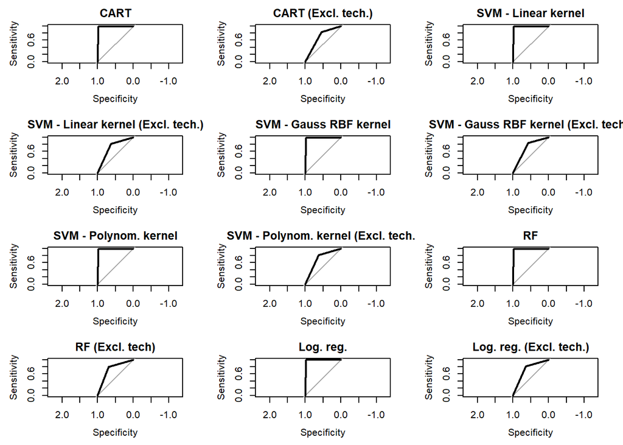

```r
# set a random seed
set.seed(123)

# when using the pROC package, both the predictions and the real data must be converted to numeric variables
data_test$tech_recency_corrected <- as.numeric(data_test$tech_recency_corrected)
data_test2$tech_recency_corrected <- as.numeric(data_test2$tech_recency_corrected)
pred_CART <- as.numeric(pred_CART)
pred_CART_notech <- as.numeric(pred_CART_notech)
predictions_SVMlin <- as.numeric(predictions_SVMlin)
predictions_SVMlin_notech <- as.numeric(predictions_SVMlin_notech)
predictions_SVMgauss <- as.numeric(predictions_SVMgauss)
predictions_SVMgauss_notech <- as.numeric(predictions_SVMgauss_notech)
predictions_SVMpolynom <- as.numeric(predictions_SVMpolynom)
predictions_SVMpolynom_notech <- as.numeric(predictions_SVMpolynom_notech)
pred_rf <- as.numeric(pred_rf)
pred_rf_notech <- as.numeric(pred_rf_notech)
pred_classes_logreg <- as.numeric(pred_classes_logreg)
pred_classes_logreg_step <- as.numeric(pred_classes_logreg_step)
pred_classes_logreg_notech <- as.numeric(pred_classes_logreg_notech)

# obtain the ROC curves for the model predictions
par(mfrow=c(4,3))
ROC_CART<-roc(data_test$tech_recency_corrected, pred_CART, plot=TRUE, main="CART")
ROC_CART_notech<-roc(data_test$tech_recency_corrected, pred_CART_notech, plot=TRUE, main="CART (Excl. tech.)")
ROC_SVMlin <-roc(data_test$tech_recency_corrected, predictions_SVMlin, plot=TRUE, main="SVM - Linear kernel")
ROC_SVMlin_notech <-roc(data_test$tech_recency_corrected, predictions_SVMlin_notech, plot=TRUE, main="SVM - Linear kernel (Excl. tech.)")
ROC_SVMgauss <-roc(data_test$tech_recency_corrected, predictions_SVMgauss, plot=TRUE, main="SVM - Gauss RBF kernel")
ROC_SVMgauss_notech <-roc(data_test$tech_recency_corrected, predictions_SVMgauss_notech, plot=TRUE, main="SVM - Gauss RBF kernel (Excl. tech.)")
ROC_SVMpolynom <-roc(data_test$tech_recency_corrected, predictions_SVMpolynom, plot=TRUE, main="SVM - Polynom. kernel")
ROC_SVMpolynom_notech <-roc(data_test$tech_recency_corrected, predictions_SVMpolynom_notech, plot=TRUE, main="SVM - Polynom. kernel (Excl. tech.)")
ROC_rf <-roc(data_test$tech_recency_corrected, pred_rf, plot=TRUE, main="RF")
ROC_rf_notech <-roc(data_test$tech_recency_corrected, pred_rf_notech, plot=TRUE, main="RF (Excl. tech)")
ROC_logreg <-roc(data_test2$tech_recency_corrected, pred_classes_logreg, plot=TRUE, main="Log. reg.")
# ROC_logreg_step <-roc(data_test2$tech_recency_corrected, pred_classes_logreg_step, plot=TRUE, main="Stepwise log. reg.")
ROC_logreg_notech <-roc(data_test2$tech_recency_corrected, pred_classes_logreg_notech, plot=TRUE, main="Log. reg. (Excl. tech.)")
```

Afterwards, the AUC values can be computed based on the obtained ROC curves:

```r
# set a random seed
set.seed(123)

# compute the AUC value for the predictions of the model
AUC_CART <-auc(ROC_CART)
AUC_CART_notech <-auc(ROC_CART_notech)
AUC_SVMlin <-auc(ROC_SVMlin)
AUC_SVMlin_notech <-auc(ROC_SVMlin_notech)
AUC_SVMgauss <- auc(ROC_SVMgauss)
AUC_SVMgauss_notech <- auc(ROC_SVMgauss_notech)
AUC_SVMpolynom <- auc(ROC_SVMpolynom)
AUC_SVMpolynom_notech <- auc(ROC_SVMpolynom_notech)
AUC_rf <- auc(ROC_rf)
AUC_rf_notech <- auc(ROC_rf_notech)
AUC_logreg <- auc(ROC_logreg)
# AUC_logreg_step <- auc(ROC_logreg_step)
AUC_logreg_notech <- auc(ROC_logreg_notech)
```

# 6 Other visuals and calculations

```r
# a<-ggplot(TechnologyData_Subset, aes(x=abstract_length)) +
#   geom_histogram() + labs(y = "# of publications", x = "Length", title = "Abstract length")
# a
#
# b<-ggplot(TechnologyData_Subset, aes(x=authorcount)) +
#   geom_histogram() + labs(y = "# of publications", x = "Number of authors", title = "Author count")
# b
#
# c<-ggplot(TechnologyData_Subset, aes(x=journal_h_index)) +
#   geom_histogram() + labs(y = "# of publications", x = "Value of the index", title = "Journal h-index")
# c
#
# d<-ggplot(TechnologyData_Subset, aes(x=journal_impact_score)) +
#   geom_histogram() + labs(y = "# of publications", x = "Value of the score", title = "Journal impact score")
# d
#
# e<-ggplot(TechnologyData_Subset, aes(x=journal_impact_score)) +
#   geom_histogram() + labs(y = "# of publications", x = "# in the ranking", title = "Journal overall ranking")
# e
#
# f<-ggplot(TechnologyData_Subset, aes(x=journal_sjr)) +
#   geom_histogram() + labs(y = "# of publications", x = "Value of the indicator", title = "Journal SJR indicator")
# f
#
# g<-ggplot(TechnologyData_Subset, aes(x=number_affiliations)) +
#   geom_histogram() + labs(y = "# of publications", x = "Number", title = "Number of affiliations")
# g
#
# h<-ggplot(TechnologyData_Subset, aes(x=number_keywords)) +
#   geom_histogram() + labs(y = "# of publications", x = "Number", title = "Number of keywords")
# h
#
# i<-ggplot(TechnologyData_Subset, aes(x=ratio_citations)) +
#   geom_histogram() + labs(y = "# of publications", x = "Ratio", title = "Ratio of citations")
# i
#
# j<-ggplot(TechnologyData_Subset, aes(x=timescited)) +
#   geom_histogram() + labs(y = "# of publications", x = "# of times cited", title = "Amount of citations")
# j
#
# k<-ggplot(TechnologyData_Subset, aes(x=title_length)) +
#   geom_histogram() + labs(y = "# of publications", x = "Length", title = "Title length")
# k
#
# l<-ggplot(TechnologyData_Subset, aes(x=year)) +
#   geom_histogram() + labs(y = "# of publications", x = "Year", title = "Publication year")
# l
```

```r
# require(gridExtra)
# grid.arrange(a, b, c, d, e, f, g, h, i, j, k, l, ncol=3)
```

```r
# w <- ggplot(data = TechnologyData_Subset, aes( x = reorder(pubtype,pubtype,function(x) length(x)))) + geom_bar() + labs(y = "# of publications", x="", title = "Publication type") + coord_flip()
# w
#
# x <- ggplot(data = TechnologyData_Subset, aes( x = reorder(openaccess,openaccess,function(x) length(x)))) + geom_bar() + labs(y = "# of publications", x="", title = "Open access?") + coord_flip()
# x
#
# y <- ggplot(data = TechnologyData_Subset, aes( x = reorder(technology,technology,function(x) length(x)))) + geom_bar() + labs(y = "# of publications", x="", title = "Technology") + coord_flip()
# y
#
# z <- ggplot(data = TechnologyData_Subset, aes( x = reorder(tech_recency_corrected,tech_recency_corrected,function(x) length(x)))) + geom_bar() + labs(y = "# of publications", x="", title = "Recency") + coord_flip()
# z
```

```r
# grid.arrange(w, x, y, z, ncol=2)
```

```r
# TechnologyData_Subset %>% group_by(technology) %>% summarise(Percentage=n()/nrow(.))
```

```r
# varimp_logreg <- varImp(logreg_notech, scale=TRUE)
# varimp_cart <- varImp(tree_notech, scale=TRUE)
# varimp_rf <- varImp(rf_notech, scale=TRUE)
```

````r
# # variable importance for gaussian kernel svm without technology
# set.seed(123)
#
# # run the model
# M_rbfdot <- fit(tech_recency_corrected~., data=data_train_notech, model="ksvm", kernel="rbfdot")
#
# # predict using the test data
# predictions_rbfdot <- predict(M_rbfdot, data_train_notech, type="prob")
# # save the predictions
# pred_rbfdot <- vector()
# for(i in 1:nrow(predictions_rbfdot)){
#   if  (predictions_rbfdot[i] >= 0.5){
#     pred_rbfdot[i] = 0
#   } else {
#     pred_rbfdot[i] = 1
#   }
# }
# pred_rbfdot <- factor(pred_rbfdot, levels = c(0, 1))
# # generate a confusion matrix
# CM_rbfdot <- confusionMatrix(pred_rbfdot, data_train_notech$tech_recency_corrected, mode = "everything")
# CM_rbfdot
#
#
# # calculate variable importance
# svm.imp_rbfdot <- Importance(M_rbfdot, data=data_train_notech, method="sensv")
# print(round(svm.imp_rbfdot$imp,digits=2))
# ```
# ```{r}
# # variable importance for linear kernel svm without technology
# set.seed(123)
# library(rminer)
#
# # run the model
# M_lin <- fit(tech_recency_corrected~., data=data_train_notech, model="ksvm", kernel="vanilladot")
#
# # predict using the test data
# predictions_lin <- predict(M_lin, data_train_notech, type="prob")
# # save the predictions
# pred_lin <- vector()
# for(i in 1:nrow(predictions_lin)){
#   if  (predictions_lin[i] >= 0.5){
#     pred_lin[i] = 0
#   } else {
#     pred_lin[i] = 1
#   }
# }
# pred_lin <- factor(pred_lin, levels = c(0, 1))
# # generate a confusion matrix
# CM_lin <- confusionMatrix(pred_lin, data_train_notech$tech_recency_corrected, mode = "everything")
# CM_lin
#
#
# # calculate variable importance
# svm.imp_lin <- Importance(M_lin, data=data_train_notech, method="sensv")
# print(round(svm.imp_lin$imp,digits=2))
````